# Apuntes R

### 2. Visualizar el contenido de un dataframe

- `View(datos)` → abre una nueva pestaña con la base de datos.
- `glimpse(datos)` (del paquete tydiverse) → muestra el número de filas y de columnas, el nombre de las variables, su clase y los primeros valores de cada una de ellas.

```
## Rows: 29,201
## Columns: 10
## $ ESTUDIO  <dbl+lbl> 3411, 3411, 3411, 3411, 3411, 3411, 3411, 3411, 3411, 341…
## $ REGISTRO <dbl> 492777, 70655, 46423, 103464, 112810, 126567, 137692, 182178,…
## $ CUES     <dbl> 29043, 5848, 3893, 8711, 9517, 10736, 11573, 14839, 16793, 17…
## $ CCAA     <dbl+lbl> 1, 1, 1, 1, 1, 1, 1, 1, 1, 1, 1, 1, 1, 1, 1, 1, 1, 1, 1, …
## $ PROV     <dbl+lbl> 4, 4, 4, 4, 4, 4, 4, 4, 4, 4, 4, 4, 4, 4, 4, 4, 4, 4, 4, …
## $ MUN      <dbl+lbl>  0,  0,  0,  0,  0,  0,  0,  0,  0,  0,  0,  0,  0,  0,  …
## $ CAPITAL  <dbl+lbl> 3, 3, 3, 3, 3, 3, 3, 3, 3, 3, 3, 3, 3, 3, 3, 3, 3, 3, 3, …
## $ TAMUNI   <dbl+lbl> 1, 1, 3, 3, 3, 3, 3, 3, 3, 3, 3, 3, 3, 3, 3, 3, 3, 3, 1, …
## $ ENTREV   <dbl+lbl> 0, 0, 0, 0, 0, 0, 0, 0, 0, 0, 0, 0, 0, 0, 0, 0, 0, 0, 0, …
## $ TIPO_TEL <dbl+lbl> 2, 2, 2, 2, 2, 2, 2, 2, 1, 2, 2, 2, 2, 2, 2, 2, 2, 2, 2, …
```

- `dim(datos)` → permite conocer el número de filas y de columnas.

```
## [1] 29201   228
```

- `summary(datos)` → muestra los descriptivos principales de cada una de las variables del dataframe (media y cuartiles).

```
##     ESTUDIO        REGISTRO           CUES            CCAA
##  Min.   :3411   Min.   :   229   Min.   :    1   Min.   : 1.000
##  1st Qu.:3411   1st Qu.: 86385   1st Qu.: 7301   1st Qu.: 4.000
##  Median :3411   Median :177688   Median :14601   Median : 9.000
##  Mean   :3411   Mean   :206694   Mean   :14601   Mean   : 8.062
##  3rd Qu.:3411   3rd Qu.:307076   3rd Qu.:21901   3rd Qu.:12.000
##  Max.   :3411   Max.   :494973   Max.   :29201   Max.   :19.000
##       PROV
##  Min.   : 1.00
##  1st Qu.:11.00
##  Median :26.00
##  Mean   :24.67
##  3rd Qu.:36.00
##  Max.   :52.00
```

- `colnames(datos)` → lista con el nombre de todas las variables.

```
##  [1] "ESTUDIO"  "REGISTRO" "CUES"     "CCAA"     "PROV"     "MUN"
##  [7] "CAPITAL"  "TAMUNI"   "ENTREV"   "TIPO_TEL" "sexo"     "edad"
## [13] "P0A"      "ECOPER"   "ECOESP"
```

- `describe(datos)` (del paquete psych).

```
##          vars     n      mean        sd median   trimmed       mad  min    max
## ESTUDIO     1 29201   3411.00      0.00   3411   3411.00      0.00 3411   3411
## REGISTRO    2 29201 206693.59 142972.42 177688 196970.89 155275.66  229 494973
## CUES        3 29201  14601.00   8429.75  14601  14601.00  10822.98    1  29201
## CCAA        4 29201      8.06      4.66      9      7.98      4.45    1     19
## PROV        5 29201     24.67     14.30     26     24.43     17.79    1     52
## MUN         6 29201     37.74     66.98      0     20.88      0.00    0    297
## CAPITAL     7 29201      2.44      0.79      3      2.54      0.00    1      3
## TAMUNI      8 29201      3.78      1.64      4      3.75      1.48    1      7
## ENTREV      9 29201      0.00      0.00      0      0.00      0.00    0      0
## TIPO_TEL   10 29201      1.74      0.44      2      1.80      0.00    1      2
##           range  skew kurtosis     se
## ESTUDIO       0   NaN      NaN   0.00
## REGISTRO 494744  0.48    -0.89 836.67
## CUES      29200  0.00    -1.20  49.33
## CCAA         18 -0.10    -0.93   0.03
## PROV         51  0.10    -1.17   0.08
## MUN         297  2.30     4.96   0.39
## CAPITAL       2 -0.94    -0.77   0.00
## TAMUNI        6  0.15    -0.76   0.01
## ENTREV        0   NaN      NaN   0.00
## TIPO_TEL      1 -1.08    -0.83   0.00
```

- `str(datos)` → metadatos de cada una de las variables (lo que sale si le das al triángulo verde que aparece junto al nombre de la base de datos del environment).

```
## tibble [29,201 × 5] (S3: tbl_df/tbl/data.frame)
##  $ ESTUDIO : dbl+lbl [1:29201] 3411, 3411, 3411, 3411, 3411, 3411, 3411, 3411, 3411...
##    ..@ label        : chr "Código del estudio"
##    ..@ format.spss  : chr "F4.0"
##    ..@ display_width: int 4
##    ..@ labels       : Named num 3411
##    .. ..- attr(*, "names")= chr "3411"
##  $ REGISTRO: num [1:29201] 492777 70655 46423 103464 112810 ...
##   ..- attr(*, "label")= chr "Número de registro"
##   ..- attr(*, "format.spss")= chr "F6.0"
##   ..- attr(*, "display_width")= int 6
##  $ CUES    : num [1:29201] 29043 5848 3893 8711 9517 ...
##   ..- attr(*, "label")= chr "Cuestionario"
##   ..- attr(*, "format.spss")= chr "F5.0"
##   ..- attr(*, "display_width")= int 5
##  $ CCAA    : dbl+lbl [1:29201] 1, 1, 1, 1, 1, 1, 1, 1, 1, 1, 1, 1, 1, 1, 1, 1, 1, 1...
##    ..@ label        : chr "Comunidad autónoma"
##    ..@ format.spss  : chr "F2.0"
##    ..@ display_width: int 2
##    ..@ labels       : Named num [1:19] 1 2 3 4 5 6 7 8 9 10 ...
##    .. ..- attr(*, "names")= chr [1:19] "Andalucía" "Aragón" "Asturias (Principado de)" "Balears (Illes)" ...
##  $ PROV    : dbl+lbl [1:29201] 4, 4, 4, 4, 4, 4, 4, 4, 4, 4, 4, 4, 4, 4, 4, 4, 4, 4...
##    ..@ label        : chr "Provincia"
##    ..@ format.spss  : chr "F2.0"
##    ..@ display_width: int 2
##    ..@ labels       : Named num [1:52] 1 2 3 4 33 5 6 7 8 9 ...
##    .. ..- attr(*, "names")= chr [1:52] "Araba/Álava" "Albacete" "Alicante/Alacant" "Almería" ...
##  - attr(*, "label")= chr "fileNameJDS"
```

- `head(datos, 10)` → muestra las variables, su clase, los 10 primeros valores de cada uno de ellos.

```
## # A tibble: 10 × 228
##    ESTUDIO     REGISTRO  CUES CCAA       PROV    MUN     CAPITAL TAMUNI  ENTREV
##    <dbl+lbl>      <dbl> <dbl> <dbl+lbl>  <dbl+l> <dbl+l> <dbl+l> <dbl+l> <dbl+l>
##  1 3411 [3411]   492777 29043 1 [Andalu… 4 [Alm… 0 [Mun… 3 [Otr… 1 [Men… 0 [Ano…
##  2 3411 [3411]    70655  5848 1 [Andalu… 4 [Alm… 0 [Mun… 3 [Otr… 1 [Men… 0 [Ano…
##  3 3411 [3411]    46423  3893 1 [Andalu… 4 [Alm… 0 [Mun… 3 [Otr… 3 [10.… 0 [Ano…
##  4 3411 [3411]   103464  8711 1 [Andalu… 4 [Alm… 0 [Mun… 3 [Otr… 3 [10.… 0 [Ano…
##  5 3411 [3411]   112810  9517 1 [Andalu… 4 [Alm… 0 [Mun… 3 [Otr… 3 [10.… 0 [Ano…
##  6 3411 [3411]   126567 10736 1 [Andalu… 4 [Alm… 0 [Mun… 3 [Otr… 3 [10.… 0 [Ano…
##  7 3411 [3411]   137692 11573 1 [Andalu… 4 [Alm… 0 [Mun… 3 [Otr… 3 [10.… 0 [Ano…
##  8 3411 [3411]   182178 14839 1 [Andalu… 4 [Alm… 0 [Mun… 3 [Otr… 3 [10.… 0 [Ano…
##  9 3411 [3411]   216764 16793 1 [Andalu… 4 [Alm… 0 [Mun… 3 [Otr… 3 [10.… 0 [Ano…
## 10 3411 [3411]   237655 17918 1 [Andalu… 4 [Alm… 0 [Mun… 3 [Otr… 3 [10.… 0 [Ano…
## # ℹ 219 more variables: TIPO_TEL <dbl+lbl>, sexo <dbl+lbl>, edad <dbl+lbl>,
## #   P0A <dbl+lbl>, ECOPER <dbl+lbl>, ECOESP <dbl+lbl>, MEDIO_1 <dbl+lbl>,
## #   MEDIO_2 <dbl+lbl>, LEEPRENSA <dbl+lbl>, VETELE <dbl+lbl>,
## #   OYERADIO <dbl+lbl>, PRENSA <dbl+lbl>, P3AR <dbl+lbl>, TELEVISION <dbl+lbl>,
## #   P3BR <dbl+lbl>, RADIO <dbl+lbl>, P3CR <dbl+lbl>, GESTIONGOB <dbl+lbl>,
## #   GESTIONOPO <dbl+lbl>, PROBVOTO <dbl+lbl>, VOTOCORREO <dbl+lbl>,
## #   PROBPARTIDOS_1 <dbl+lbl>, PROBPARTIDOS_2 <dbl+lbl>, …
```

### 3. Modificar el fichero

#### Filter: seleccionar casos (filas)

Se usa el comando `filter`, del paquete dplyr (en tidyverse). Se establecen una serie de condiciones lógicas a partir de las cuales la función retendrá únicamente los casos (filas) que cumplen con dicha condición (*condiciones como ==, >, %in%*).

Ej.: en una base de datos donde los casos son municipios, seleccionar solo aquellos pertenecientes a Murcia o Almería:

```r
datos_2prov <- datos %>%
  filter(Provincia=="Almería" | Provincia=="Murcia")

datos_2prov <- datos %>%
  filter(id_provincia %in% c(5,35))
```

*Al usar tanto este comando como el select, conviene guardar los cambios dentro de un nuevo objeto y dejar el dataset original sin modificar*

#### Select: seleccionar variables

Se usa el comando `select`, del paquete dplyr. Esta función permite reducri el número de columnas, por lo que resulta de gran utilidad cuando tenemos datasets con muchas variables y solo vamos a trabajar con algunas de ellas.

Seleccionar una columna: `select(datos, nombre_variable)`.

Este comando permite seleccionar más de una variable a la vez: `select(datos, x1, x2, x3)`.

Tambiéns se pueden eliminar una o varias variables que no se quieran en el dataset: `select(datos, -variable)`

#### Ordenar las variables

**Variable numérica:**

- Orden ascendente:
  - Opción 1: `datos %>% arrange(variable)`
  - Opción 2: `datos <- datos[order(datos$variable), ]`
- Orden descendente:
  - Opción 1: `datos %>% arrange(desc(variable))`
  - Opción 2: `datos <- datos[order(-datos$variable), ]`
- Se pueden ordenar los datos por dos variables simultáneamente:
  - Opción 1: `datos <- datos %>% arrange(var1, var1)`
  - Opción 2: `datos <- datos[order(datos$var1, datos$var2), ]`

**Variable categórica:**

- Se usan los mismos comandos anteriores para ordenar por orden alfabético ascendente o descendente
- Orden personalizado: `mutate(variable = fct_relevel(variable, c("categoría1", "cat2", "catn")))` Ej.:

```r
mutate(partido = fct_relevel(party, c("PP", "PSOE", "VOX", "SUMAR", "Otros")))
```

## Edición de variables

### 1. Renombrar una variable

**Opción 1**:

```r
Datos <- rename(Datos, nombre_nuevo = nombre_viejo)
```

**Opción 2**:

```r
datos <- datos %>% rename(nombre_nuevo = nombre_viejo)
```

Se puede cambiar el nombre de varias variables a la vez:

```r
colnames(Datos)
```

```
## [1] "pclass"   "survived" "name"     "sex"      "age"
```

```r
Datos<-Datos %>% rename(
  clase=pclass,
  nombre=name,
  sexo=sex,
  edad=age)
```

```r
colnames(Datos)
```

```
## [1] "clase"    "survived" "nombre"   "sexo"     "edad"
```

**Opción 3**:

Se pueden renombrar las variables directamente al abrir la base de datos gracias al pipe:

```r
datos <- read_xlsx("dirección_datos-xlsx") %>%
  rename(nombre_nuevo = nombre_viejo,
         nombre_nuevo = nombre_viejo,
         ...)
```

### 2. Recodificar una variable (o crear una nueva)

Para poder recodificar y crear varaibles se usa el comando `mutate` (*de dplyr*). Este es de gran utilidad si se usa junto a comandos que permiten añadir condiciones lógicas como `ifelse` o `case_when`.

**Pasos previos antes de recodificar una variable**

Antes de recodificar una variable es necesario conocer cómo es la variable original. Para ello:

1. Se mira de qué tipo es la varible (numérica -numeric/dbl- o factor) gracias al comando `class`:

```r
class(Datos$edad)
```

```
## [1] "numeric"
```

2. Tambien conviene realizar una tabla para conocer el contenido de la variable, así como su distribución:

```r
table(Datos$clase, useNA="ifany") #La opción useNA="ifany" es opcional, y se añade para que en la tabla se muestren también los valores perdidos.
```

```
##
##   1   2   3
## 322 273 702
```

**Crear una nueva variable a partir de operaciones sobre otras existentes**

- Ej1.: calcular la edad de los encuestados a partir del año de nacimiento

```r
datos <- datos %>%
  mutate(edad = año_actual - año_nacimiento)
```

- Ej2.: crear una varieble para el porcentaje de voto de un partido a partir de los votos totales:

```r
datos <- datos %>%
  mutate(votosFO_porcentaje = votos_FO/votostotales*100)
```

**Recodificar con el comando case_when**

```r
Datos <- Datos %>%
  mutate(edad = case_when(
    edad == 29 ~ 30, # reemplaza 29 por 30
    edad == 2 ~ 3, # reemplaza 2 por 3
    TRUE ~ edad)) # Mantiene iguales los valores que no cambian.
```

```r
Datos <- Datos %>%
  mutate(clase_rec = case_when(
    clase %in% c(2, 3) ~ 0, # Si 'clase' es 2 o 3, asigna "0"
    TRUE ~ clase))

table(Datos$clase_rec)
```

```
##
##   0   1
## 975 322
```

La opción TRUE en este comando significa “todos los demás valores”. Si no se añadiera, todos los valores que no coinciden con las condiciones se enviarían a perdidos (NA).

**Recodificar con el comando ifelse**

El comando ifelse es una secuancia lógica con tres elementos. Un primer número, que es la categoría que se quiere transformar, un segundo número, que es en el que se transforma, y una tercera condición para el resto de valores. Esta puede ser otro número, NA o otra secuencia de ifelse.

```r
Datos <- Datos %>%
  mutate(edad = ifelse(edad == 29, 30, ifelse(edad == 2, 3, edad)))

Datos <- Datos %>%
  mutate(clase_rec2 = ifelse(clase == 1, 1,
                             ifelse(clase %in% c(2, 3), 0, NA)))
```

Las **variables categóricas** se recodifidan del siguente modo:

1. Transformándolas en una variable numérica:

```r
#Por separado:
Datos <- Datos %>%
  mutate(sexo = as.numeric(sexo)) %>%
  mutate(sexo = case_when(
    sexo == 1 ~ 0,
    sexo == 2 ~ 1,
    TRUE ~ sexo
  ))

#A la vez:
Datos <- Datos %>%
  mutate(as.numeric(sexo) = case_when(
    sexo == 1 ~ 0,
    sexo == 2 ~ 1,
    TRUE ~ sexo
  ))
```

*Es la opcion más útil si se quiere modificar una variable con muchas categorías*

2. Escribiendo las etiquetas entre ““:

```r
Datos <- Datos %>%
  mutate(sexo = case_when(
    sexo == "female" ~ "mujer",
    sexo == "male" ~ "hombre",
    TRUE ~ sexo
  ))
```

*Esta opción es la más cómoda si la variable tiene pocas categorías.*

3. Especificando los niveles que se quieren modificar:

```r
datos <- datos %>%
  mutate(estudios_universitarios = case_when(
    estudios %in% levels(estudios)[1:5] ~ 0,  # Agrupar niveles 1 a 5 en 0
    estudios %in% levels(estudios)[6] ~ 1,    # Agrupar nivel 6 en 1
    TRUE ~ NA_real_
  ))
```

*Esta opción es util si se quiere convertir en dicotómica una variable categórica con muchas categorías, aunque la primera opción es igual de buena en estos casos*

Otros **ejemplos** de recodificar variables:

- Se pueden utilizar símbolos lógicos como el >,<,|,& etc a la hora de recodificar variables

```r
datos<-datos %>%
  mutate(municipio_cat=ifelse(población>=20000,"Ciudad","Pueblo") %>%
           as.factor())
```

- También se pueden realizar operaciones entre variables al mismo tiempo que se recodifican. Ej.: calcular el apoyo en cada municipio a los partidos principales:

```r
elec23 <- elec23 %>%
  mutate(apoyo = case_when(
    CA=="Galicia" ~ PP+BNG+PSOE+SUMAR+VOX,
    CA=="Cataluña" ~ PP+PSOE+SUMAR+VOX+JxCAT+ERC,
    CA=="País Vasco" ~ PP+PSOE+SUMAR+VOX+PNV+BILDU,
    T ~ PP+PSOE+SUMAR+VOX),
  apoyo=apoyo/Votantes*100)
```

#### Otras opciones de mutate

1. `mutate_if`. Se hacen cambios en múltiples variables que cumplan con una característica especificada. Es especialmente útil para transformar variables de un tipo a otro. Por ejemplo:
   - Convertir todas las variables de tipo factor a carácter: `mutate_if(is.factor, as.character)`
   - Estandardizar (=0, sd=1) todas las variables numéricas del dataset: `mutate_if(is.numeric, scale)`
   - Cuando se estandariza, el valor 0 de una observación implica que esta se corresponde a la media, y el 1 que esa observación está un punto por encima de la desviación típica.
2. `mutate_at`. Cambia diferentes varaibles especificadas en un vector específico.
   - Estandarizar una variable: `mutate_at (c("n", "edad"), scale)`
   - Convertir una escala en logarítmica: `mutate_at (c(“pib", “poblacion"), log)`
3. `mutate_all`. Permite hacer cambios en todas las variables de un dataframe. Ej.: `mutate_all(as.character)`
4. `across`. Permite hacer cambios a varias variables a la vez dentro de la función básica de mutate. Ejs.:
   - `mutate(across(c(n, edad), round))`
   - `mutate(across(where(is.numeric), round))`
   - `mutate(across(starts_with(“nombr"), tolower))`

### 3. Añadir etiquetas a la variable

Ver las etiquetas de una variable: `attr(datos$var, "labels")`:

**Para cambiar las etiquetas se usa el comando factor** *(de dyplr)*

```r
datos <- datos %>%
  mutate(variable = factor(variable,
                    levels = c(1,2,3),
                    labels = c("Etiqueta1","Etiqueta2","Eriqueta3")))
```

- `levels` = c(1,2,3) indica el conjunto de números correspondientes con los valores de cada categoría de la variable.
- `labels` =c(“Etiqueta1”…) indica las etiquetas correspondientes con cada valor especificado anteriormente. Por ejemplo, en este caso a la categoría de la variable que se identifica con un 1 se le asignaría la etiqueta “Etiqueta1”.
- Ej. de cómo añadir etiquetas:

```r
table(datos$mujer)
```

```
##
##     0     1
## 15023 14178
```

```r
datos <- datos %>%
  mutate(mujer = factor(mujer, levels = c(0, 1), labels = c("Hombre","Mujer")))

table(datos$mujer)
```

```
##
## Hombre  Mujer
##  15023  14178
```

Si se quiere etiquetar algún carácter de una variable numérica sin transformarla en factor, se puede usar el siguiente comando:

```r
library(labelled)
val_labels(datos$variable) <- c(Etiqueta1 = 0, Etiqueta2 = 1)
```

Este comando también es útil en el caso de escalas: por ejemplo, en la escala de ideología del 1 al 10 para poner que el 1 es extrema izquierda y el 10 extrema derecha, pero dejarlo como numérico y sin necesidad de etiquetar todas las categorías.

```r
class(datos$ideol)
```

```
## [1] "numeric"
```

```r
val_labels(datos$ideol) <- c(Extrema_izq = 1, Extrema_dcha = 10)

class(datos$ideol)
```

```
## [1] "haven_labelled" "vctrs_vctr"     "double"
```

```r
val_labels(datos$ideol)
```

```
##  Extrema_izq Extrema_dcha
##            1           10
```

## Análisis descriptivo

### 1. Estadísticos básicos

Lista con los estadísticos descriptivos básicos: `summary()`

```r
summary(datos$edad)
```

```
##    Min. 1st Qu.  Median    Mean 3rd Qu.    Max.
##   18.00   40.00   52.00   51.48   64.00   98.00
```

También se puede obtener un único estadístico de interés: `min()`, `max()`, `median()`, `mean()`, `sd()`

### 2. Tablas de frecuencias

Con el comando `table`:

```r
table(datos$variable)
```

- Ej.:

```r
table(datos$estudios)
```

```
##
## sin_estudios     primaria    fp basica  secundaria2     fp medio   superiores
##          496         1425         3768         4226         5859        13266
```

Si queremos ver también los valores perdidos de la variable, se añade al comando original la opción `useNA = "ifany"`:

```r
table(datos$estudios, useNA = "ifany")
```

```
##
## sin_estudios     primaria    fp basica  secundaria2     fp medio   superiores
##          496         1425         3768         4226         5859        13266
##         <NA>
##          161
```

Con el comando `count`:

```r
datos %>% count(variable)
```

- Ej.:

```r
datos %>% count(estudios)
```

```
## # A tibble: 7 × 2
##   estudios         n
##   <fct>        <int>
## 1 sin_estudios   496
## 2 primaria      1425
## 3 fp basica     3768
## 4 secundaria2   4226
## 5 fp medio      5859
## 6 superiores   13266
## 7 <NA>           161
```

*La explicación de cómo hacer tablas de frecuencias bivariadas, así como su interpretación, está en el apartado de análisis bivariado*

## Análisis bivariado

### 1. Prueba estadística para la diferencia de medias (T-test)

#### 1.1. En R

**Test de una media**:

El objetivo de este tipo de test es comprobar si la media poblacional de una variable se corresponde con una determinada cifra.

```r
t.test(datos$variable, mu = 5, conf.level = 0.99)
```

- `mu = número` es donde se indica el valor de la media para el cual se quiere comprobar si la media poblacional es significativamente distinta. Es decir, si se quiere comprobar si la media es igual a 5, se escribirá `mu = 5`.
- `conf.level` sirve para establecer un intervalo de confianza específico. Si no se añade esta opción, el intervalo será al 95%.

```r
t.test(datos$ideol, mu=5.5)
```

```
##
##  One Sample t-test
##
## data:  datos$ideol
## t = -43.622, df = 28265, p-value < 2.2e-16
## alternative hypothesis: true mean is not equal to 5.5
## 95 percent confidence interval:
##  4.785116 4.846597
## sample estimates:
## mean of x
##  4.815857
```

En este caso, se puede decir que al 95% de confianza la media ideológica de la población es distinta de 5.5 (en una escala del 1 al 10). Se sabe por tres motivos:

- El p-value es < de 0,05
- El valor de t < -1,96
- En el intervalo de confianza no se incluye el 5.5

*La explicación del por qué está en el apartado de la teoría*

**Test de proporciones**: para variables dicotómicas.

Lo que se intenta con este tipo de test no es comprobar si una determinada cifra se incluye dentro de la media poblacional, sino si una variable alcanza un determinado porcentaje.

P.ej., para saber si el PP puede alcanzar un 35% de los votos, se crea una variable dicotómica donde 0 es no votarlo y 1 sí. Después, se hace un ttest como el anterior, pero en el mu se especifica el porcentaje que se quiere comprobar si se alcanza (0.35 en este caso).

```r
t.test(datos$intvoto_pp, mu=0.35)
```

```
##
##  One Sample t-test
##
## data:  datos$intvoto_pp
## t = -8.4891, df = 23428, p-value < 2.2e-16
## alternative hypothesis: true mean is not equal to 0.35
## 95 percent confidence interval:
##  0.3180496 0.3300361
## sample estimates:
## mean of x
## 0.3240429
```

Los resultados se interpretan igual que en el test de una media.

**Test de dos medias**

La hipótesis nula en este tipo de prueba es que las dos medias son iguales y la hipótesis alternativa es que no lo son.

```r
t.test(datos$var1 ~ datos$var2)
```

- `var2` es la variable dicotómica que divide a la muestra en los dos grupos de interés, para los cuales se tratará de averiguar si la media de la
- `var1` (variable numérica) es igual en ambos o no.

```r
t.test(datos$ideol ~ datos$hombre)
```

```
##
##  Welch Two Sample t-test
##
## data:  datos$ideol by datos$hombre
## t = -3.7778, df = 27496, p-value = 0.0001586
## alternative hypothesis: true difference in means between group Mujer and group Hombre is not equal to 0
## 95 percent confidence interval:
##  -0.1806671 -0.0572345
## sample estimates:
##  mean in group Mujer mean in group Hombre
##             4.754256             4.873207
```

**Comparación de medias para dos variables numéricas**

Si son **muestras independientes**:

```r
t.test(datos$variable1, datos$variable2)
```

En el caso de **muestras dependientes**, el comando es el siguiente:

```r
t.test(datos$variable1, datos$variable2, paired = TRUE)
```

La prueba t pareada se utiliza cuando las medias que estamos comparando no son independientes. En otras palabras:

- Correnponden al mismo conjunto de sujetos en dos momentos diferentes (por ejemplo, antes y después de un tratamiento).
- Se comparan dos variables medidas en las mismas personas o unidades (las mismas personas opinan o responden sobre dos cosas diferentes).

Ej.: comprobar si las personas tienen la misma probabilidad de votar al PP y VOX:

```r
t.test(datos$prop_vox, datos$prop_pp, paired=TRUE)
```

```
##
##  Paired t-test
##
## data:  datos$prop_vox and datos$prop_pp
## t = -69.828, df = 28775, p-value < 2.2e-16
## alternative hypothesis: true mean difference is not equal to 0
## 95 percent confidence interval:
##  -1.652107 -1.561891
## sample estimates:
## mean difference
##       -1.606999
```

*Cálculo manual de los intervalos de confianza:*

La fórmula de los intervalos es: media muestral ± valor crírico (σ)*error estandar

Para calcular el error, se utiliza el comando `std.error`de la librería `plotrix`:

```r
std.error(datos$variable)
```

En el ejemplo usado en el test de una media, el error se calcularía del siguiete modo:

```r
std.error(datos$ideol)
```

```
## [1] 0.01568334
```

#### 1.2. Teoría

A la hora de iterpretar los resultados de una prueba estadística, podemos fijarnos en tres cuestiones (relacionadas entre sí): el valor crítico, el nivel de significatividad o alpha y el intervalo de confianza.

- *Nivel de confianza*: es la probabilidad de que el parámetro a estimar se encuentre en el intervalo de confianza.
- *Alpha*: es la probabilidad de quedarse fuera de ese intervalo (en términos sustantivos, la probabilidad de rechazar la hipótesis nula cuando es cierta.
- *Valor crítico*: indica el número de desviaciones estándar que cubren el área bajo la curva para un determinado nivel de confianza. Por ejemplo, para un IC del 95%, este valor crítico indica los límites dentro de los cuales se encuentra el 95% de las observaciones en una distribución normal. Establece donde empieza y dónde termina la zona de rechazo de la hipótesis.

| Nivel de confianza | Alpha | Valor crítico |
| --- | --- | --- |
| 95% | 5 - 2,5% | 1,96 |
| 99% | 1 - 0,5% | 2,57 |
| 99,9% | 0,1 - 0,05% | 3,27 |

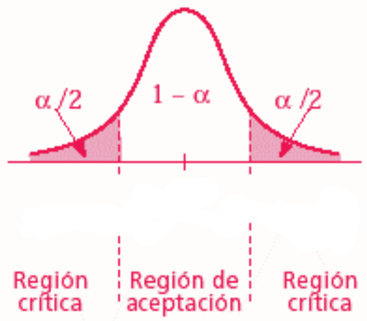

Intervalos de confianza

El *intervalo de confianza* indica, para un determiando nivel de confianza, el rango en el que se moverá la media real de un determinado rasgo para el universo estudiado, mientras que la media que se puede calcular a partir de una muestra indica únicamente el valor medio del rasgo de esa muestra. Es decir, si tomamos un intervalo de confianza del 95%, en el 95% de ocasiones la media real del universo de estudio se moverá entre los límites establecidos por el intervalo de confianza. Se emplean estos intervalos ya que la única forma de conocer el valor medio real de un determinado rasgo de una población completa es mediante un censo en el que se incluya a toda esa población, pero es imposible de conocer de forma exacta tomando solo una muestra poblacional.

Por ejemplo, si para la media idológica tenemos un intervalo que va del 4,5 al 5 para un nivel de confianza del 95%, lo que quiere decir es que, en el caso de realizar 100 encuestas independientes a una población, en 95 de estas encuestas la media muestral tendrá un valor situado entre el 4,5 y el 5, y en otros 5 caso será superior o inferior a estas cifras.

### 2. Análisis de correlación

#### 2.1. En R

Los análisis de correlación buscan averiguar si existe relacion entre dos variables continuas.

**Covarianza:**

```r
cov(datos$var1, datos$var2)
```

Ej. Se quiere comprobar la relación entre en índice de corrupcion de un páis (*cpi*, donde 0=más corrupto; 10=menos corrupto) y el índice de desarrollo humano (*hdi*, donde 0=más bajo; 1=más alto).

```r
cov(data$cpi, data$hdi)
```

```
## [1] 0.2435116
```

**Correlación de Pearson:**

La funión para calcular la correlación es `cor()` *(funciona igual que el comando cov)*. Sin embargo, para poder interpretar más adecuadamente los resultados de la correlacion conviene realizar un test para comprobar si dicha correlación es estadísticamente significativa. Las hipótesis de este test son:

- H<sub>0</sub>= la correlación es igual a 0, así que no hay relación
- H<sub>1</sub>= la correlación es significativamente distinta de 0

```r
cor.test(datos$var1, datos$var2)
```

Ej.:

```r
cor(data$cpi, data$hdi) # devuelve el valor de la correlación
```

```
## [1] 0.7238193
```

```r
cor.test(data$cpi, data$hdi) # hace un test
```

```
##
##  Pearson's product-moment correlation
##
## data:  data$cpi and data$hdi
## t = 13.186, df = 158, p-value < 2.2e-16
## alternative hypothesis: true correlation is not equal to 0
## 95 percent confidence interval:
##  0.6406049 0.7902298
## sample estimates:
##       cor
## 0.7238193
```

Los resultados muestran que la correlación entre ambas variables tiene un valor de 0,72. El test arroja tres resultados:

- t=13,186 –> t>3,26
- p<2.2e-16 –> p<0,001
- IC= [0.6406049, 0.7902298]

Basándonos en estos resultados, podemos rechazar la hipótesis nula y afirmar que la correlación es significativamente distinta de cero para un nivel de confianza del 99,9%

**Correlación de más de dos variables a la vez:**

1. Correlación entre todas las variables del dataset. Es fundamental que sean TODAS numéricas.

```r
cor(Data)
```

```
##             mpg        cyl       disp         hp        drat         wt
## mpg   1.0000000 -0.8521620 -0.8475514 -0.7761684  0.68117191 -0.8676594
## cyl  -0.8521620  1.0000000  0.9020329  0.8324475 -0.69993811  0.7824958
## disp -0.8475514  0.9020329  1.0000000  0.7909486 -0.71021393  0.8879799
## hp   -0.7761684  0.8324475  0.7909486  1.0000000 -0.44875912  0.6587479
## drat  0.6811719 -0.6999381 -0.7102139 -0.4487591  1.00000000 -0.7124406
## wt   -0.8676594  0.7824958  0.8879799  0.6587479 -0.71244065  1.0000000
## qsec  0.4186840 -0.5912421 -0.4336979 -0.7082234  0.09120476 -0.1747159
## vs    0.6640389 -0.8108118 -0.7104159 -0.7230967  0.44027846 -0.5549157
## am    0.5998324 -0.5226070 -0.5912270 -0.2432043  0.71271113 -0.6924953
## gear  0.4802848 -0.4926866 -0.5555692 -0.1257043  0.69961013 -0.5832870
## carb -0.5509251  0.5269883  0.3949769  0.7498125 -0.09078980  0.4276059
##             qsec         vs          am       gear        carb
## mpg   0.41868403  0.6640389  0.59983243  0.4802848 -0.55092507
## cyl  -0.59124207 -0.8108118 -0.52260705 -0.4926866  0.52698829
## disp -0.43369788 -0.7104159 -0.59122704 -0.5555692  0.39497686
## hp   -0.70822339 -0.7230967 -0.24320426 -0.1257043  0.74981247
## drat  0.09120476  0.4402785  0.71271113  0.6996101 -0.09078980
## wt   -0.17471588 -0.5549157 -0.69249526 -0.5832870  0.42760594
## qsec  1.00000000  0.7445354 -0.22986086 -0.2126822 -0.65624923
## vs    0.74453544  1.0000000  0.16834512  0.2060233 -0.56960714
## am   -0.22986086  0.1683451  1.00000000  0.7940588  0.05753435
## gear -0.21268223  0.2060233  0.79405876  1.0000000  0.27407284
## carb -0.65624923 -0.5696071  0.05753435  0.2740728  1.00000000
```

2. Si solo se quiere la relación entre varias variables concretas, se puede hacer de forma manual del siguiente modo:

```r
x <- Data[c(1:3, 5)]
y <- Data[6:8]
cor(x, y)
```

```
##              wt        qsec         vs
## mpg  -0.8676594  0.41868403  0.6640389
## cyl   0.7824958 -0.59124207 -0.8108118
## disp  0.8879799 -0.43369788 -0.7104159
## drat -0.7124406  0.09120476  0.4402785
```

**Visualización de correlaciones:**

Además de usar funciones de cálculo, suele ser de gran ayuda visualizar las correlaciones entre variables gráficamente.

- Nube de puntos (dos variables):

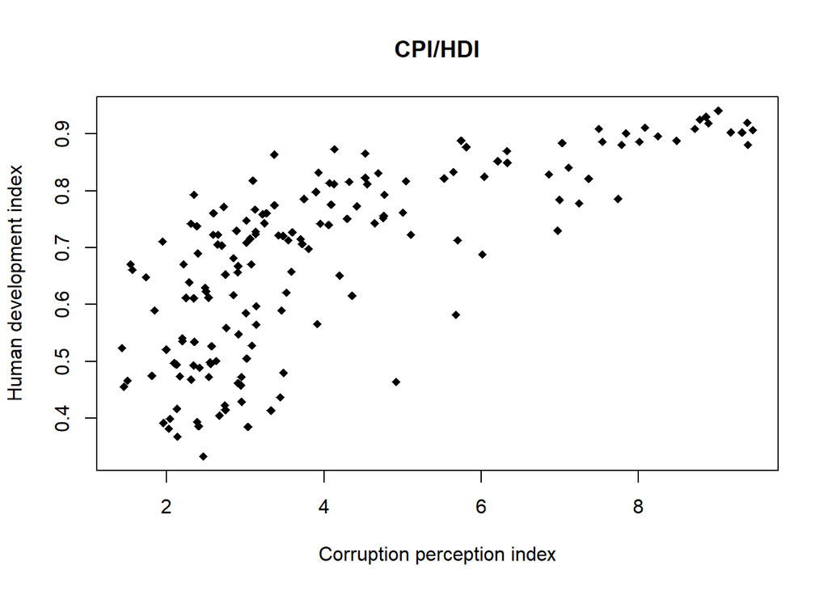

```r
plot(data$cpi, data$hdi, #Los datos que se van a usar para hacer el gráfico
     main = "CPI/HDI", #El título del gráfico
     xlab = "Corruption perception index", #El texto del eje X
     ylab = "Human development index", #El texto del eje Y
     pch = 18) #Establece la forma de los puntos (triángulos, círculos, x...)
```

- Correlaciones para más de dos variables a la vez:

```r
library(corrgram)
corrgram(datos)
```

Ej.:

[figure not shown]

```r
corrgram(Data)
```

*El comando cuenta con numerosas argumentos extra para modificar y mejorar la visualización del gráfico final (ver ?corrgram). P. ej.:*

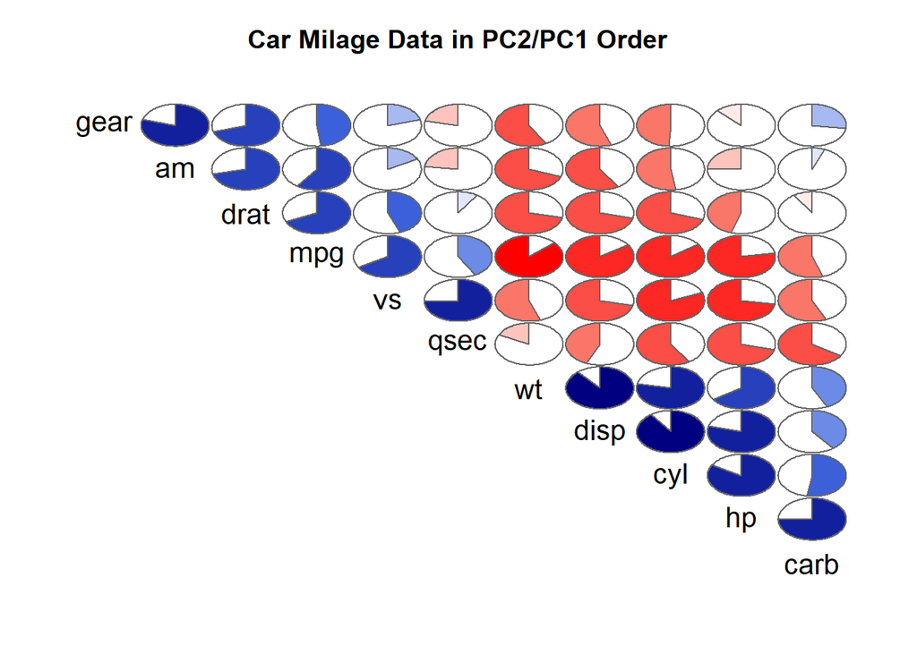

```r
corrgram(Data, order=TRUE, lower.panel=NULL,
         upper.panel=panel.pie, text.panel=panel.txt,
         main="Car Milage Data in PC2/PC1 Order")
```

#### 2.2. Teoría

Si queremos analizar la dependencia entre dos **variables continuas** XX e YY, no podemos estudiar sus distribuciones por separado, sino que debemos hacerlo de manera conjunta. Para ello, definimos una variable estadística bidimensional (X,Y)(X,Y), cuyos valores serán todos los pares formados por los valores de las variables XX e YY.

La representación gráfica más utilizada para examinar la relación entre dos variables numéricas es el diagrama de dispersión. Este consiste en representar, sobre un plano cartesiano, los puntos correspondientes a los pares de valores ($x_{i}$, $y_{i}$) de la variable bidimensional. Estas nubes de puntos nos permiten visualizar el tipo de relación existente entre las variables (lineal, exponencial, positiva, negativa, etc.). Si además queremos cuantificar la intensidad de dicha relación, es necesario recurrir a medidas estadísticas, como la covarianza muestral o el coeficiente de correlación.

La **covarianza** de una variable bidimensional se obtiene promediando los productos de las desviaciones de cada valor con respecto a las medias de XX e YY. Una vez calculadas las medias, podemos calcular la covarianza siguiendo la siguiente fórmula:

$$cov_{x,y} =
\frac{\sum\limits_{i=1}^{n}{(x_i-\overline{x}) \cdot (y_i-\overline{y})}
}{n-1}$$

El valor de la covarianza nos indica lo siguiente:

- Si cov>0, relación lineal creciente entre las variables
- Si cov<0, relación lineal decreciente entre las variables
- Si cov=0, no existe relación lineal entre las variables

El problema de esta medida es que depende de las unidades. Imaginemos que las unidades de la variable x son *cm* y las de la variable y son *gr*. En este caso, las unidades de la covarianza serán *cm × gr*, y si cambiamos la escala de las variables, la covarianza también cambiará. Esto hace que el valor de la covarianza sea difícil de interpretar. (la variazna es la distancia de los puntos hacia los ejes. La covarianza es la distancia de los puntos entre sí)

Para evitar este problema, es recomendable utilizar una medida normalizada, como el coeficiente de **correlación de Pearson**, que toma valores entre -1 y 1, donde:

- ρ = 1 indica una relación lineal perfecta y positiva
- ρ = -1 indica una relación lineal perfecta y negativa
- ρ = 0 indica ausencia de relación entre las variables

$$\rho = \frac{\text{cov}(X,Y)}{\sigma_x
\sigma_y}$$

**Correlación no implica causalidad**

La correlación entre dos variables v1 y v2 puede deberse a:

- Relación causal: V1 es la causa, V2 el efecto (o viceversa)
- Azar
- Variable interviniente (confounding factor):
  - [Relaciones espúreas](http://www.tylervigen.com/spurious-correlations): es una correlación aparente entre dos variables que en realidad es causada por la influencia de una tercera variable, conocida como variable de confusión. Aunque las dos variables parecen estar relacionadas, su relación no es causal.
  - [Paradoja de Simpson](https://upload.wikimedia.org/wikipedia/commons/f/fb/Simpsons_paradox_-_animation.gif): ocurre cuando una tendencia observada en varios grupos desaparece o se invierte al combinar los datos de esos grupos. Esto sucede debido a la influencia de una variable oculta o de confusión que afecta la interpretación de la relación entre las variables. Aquí tenéis un [ejemplo muy conocido](https://rpubs.com/dawnwp/1081716).

### 3. Tablas de contingencia

#### 3.1. En R

Permite conocer la relación existente entre variables categóricas. Para ello nos valemos de las tablas de contingencia, donde se muestran las frecuencias de dos variables.

**La función table()**

1. Crear la tabla con las dos variables y guardarla:

```r
tabla <- table(datos$var1, datos$var2)
```

Ej.:

```r
tabla <- table(datos$situ_lab, datos$hombre)  # (filas, columnas)
tabla
```

```
##
##                     Mujer Hombre
##   Trabajador/a       7552   9549
##   Pensionista        3515   3854
##   Desempleado/a      1424    846
##   Estudiante          502    617
##   Trabajo doméstico   994     30
##   Otra situación      182    113
```

2. Crear la tabla de frecuencias:
- `prop.table(tabla)` #porcentaje de tabla (el % sobre el total)
- `prop.table(tabla, 1)` # porcentajes de fila (el 100% lo suman las filas)
- `prop.table(tabla, 2)` # porcentajes de columna (el 100% lo suman las columnas) Para leer estas tablas adecuadamente, hay que fijarse si el 100% lo suman las filas, las columnas o toda la tabla.

Ej.:

```r
prop.table(tabla)
```

```
##
##                           Mujer      Hombre
##   Trabajador/a      0.258825142 0.327267119
##   Pensionista       0.120467475 0.132085818
##   Desempleado/a     0.048803893 0.028994448
##   Estudiante        0.017204743 0.021146069
##   Trabajo doméstico 0.034066763 0.001028172
##   Otra situación    0.006237576 0.003872781
```

Indica el porcentaje de cada subgrupo sobre el total de la muestra. Por ejemplo, de esta tabla se puede deducir que del total de la población un 25% son mujeres trabajadoras.

```r
prop.table(tabla, 1)
```

```
##
##                          Mujer     Hombre
##   Trabajador/a      0.44161160 0.55838840
##   Pensionista       0.47699824 0.52300176
##   Desempleado/a     0.62731278 0.37268722
##   Estudiante        0.44861483 0.55138517
##   Trabajo doméstico 0.97070312 0.02929688
##   Otra situación    0.61694915 0.38305085
```

Indica la composición de género de cada una de las situaciones laborales. Por ejemplo, de los trabajadores un 44% son mujeres y un 56% hombres.

```r
prop.table(tabla, 2)
```

```
##
##                           Mujer      Hombre
##   Trabajador/a      0.532994566 0.636218269
##   Pensionista       0.248076787 0.256779266
##   Desempleado/a     0.100501094 0.056366180
##   Estudiante        0.035429459 0.041108668
##   Trabajo doméstico 0.070153151 0.001998801
##   Otra situación    0.012844943 0.007528816
```

**Otras tablas: xtabs vs CrossTable** (mejor usar esta)

- `xtabs()`:

```r
tabla2 <- xtabs(~var1+var2, data = datos) #Crear y guardar la tabla
ftable(tabla2) #Visualizar la tabla
summary(tabla2) #Para ver los estadísticos de la tabla (como el chi2 y el p-valor)
```

Ej.:

```r
tabla2 <- xtabs(~situ_lab+hombre, data=datos)
ftable(tabla2)
```

```
##                   hombre Mujer Hombre
## situ_lab
## Trabajador/a              7552   9549
## Pensionista               3515   3854
## Desempleado/a             1424    846
## Estudiante                 502    617
## Trabajo doméstico          994     30
## Otra situación             182    113
```

```r
summary(tabla2)
```

```
## Call: xtabs(formula = ~situ_lab + hombre, data = datos)
## Number of cases in table: 29178
## Number of factors: 2
## Test for independence of all factors:
##  Chisq = 1308.3, df = 5, p-value = 9.93e-281
```

- `CrossTable()`:

```r
library(gmodels)
tabla3 <- CrossTable(datos$var1, datos$var2, #Las variables
                     digits = 1, #El número de decimales de la tabla
                     #Otras opciones de la tabla,
                     format = "SPSS") #El formato de salida de la tabla
```

Ej.:

```r
CrossTable(datos$situ_lab, datos$hombre, digits=1, expected=T, asresid=TRUE, chisq=TRUE, prop.chisq=F, format="SPSS")
```

```
##
##    Cell Contents
## |-------------------------|
## |                   Count |
## |         Expected Values |
## |             Row Percent |
## |          Column Percent |
## |           Total Percent |
## |           Adj Std Resid |
## |-------------------------|
##
## Total Observations in Table:  29178
##
##                   | datos$hombre
##    datos$situ_lab |    Mujer  |   Hombre  | Row Total |
## ------------------|-----------|-----------|-----------|
##      Trabajador/a |     7552  |     9549  |    17101  |
##                   |   8304.3  |   8796.7  |           |
##                   |     44.2% |     55.8% |     58.6% |
##                   |     53.3% |     63.6% |           |
##                   |     25.9% |     32.7% |           |
##                   |    -17.9  |     17.9  |           |
## ------------------|-----------|-----------|-----------|
##       Pensionista |     3515  |     3854  |     7369  |
##                   |   3578.4  |   3790.6  |           |
##                   |     47.7% |     52.3% |     25.3% |
##                   |     24.8% |     25.7% |           |
##                   |     12.0% |     13.2% |           |
##                   |     -1.7  |      1.7  |           |
## ------------------|-----------|-----------|-----------|
##     Desempleado/a |     1424  |      846  |     2270  |
##                   |   1102.3  |   1167.7  |           |
##                   |     62.7% |     37.3% |      7.8% |
##                   |     10.1% |      5.6% |           |
##                   |      4.9% |      2.9% |           |
##                   |     14.1  |    -14.1  |           |
## ------------------|-----------|-----------|-----------|
##        Estudiante |      502  |      617  |     1119  |
##                   |    543.4  |    575.6  |           |
##                   |     44.9% |     55.1% |      3.8% |
```

[output cut: 18 more lines]

```
##      Column Total |    14169  |    15009  |    29178  |
##                   |     48.6% |     51.4% |           |
## ------------------|-----------|-----------|-----------|
##
##
## Statistics for All Table Factors
##
##
## Pearson's Chi-squared test
## ------------------------------------------------------------
## Chi^2 =  1308.347     d.f. =  5     p =  9.930323e-281
##
##
##
##        Minimum expected frequency: 143.2537
```

*Para comprobar qué opciones se pueden aplicar a la tabla, conviene mirar `?(CrossTable)`*

Ej. de interpretación de los residuos ajustados: en la celda de mujer y trabajadoras, los residuos ajustados son de -17,9. Esta cifra es inferior a -3,27, por lo que podemos decir que con un nivel de confianza del 99,9% las mujeres se encuentran infrarepresentadas (el símbolo es negativo) dentro del grupo de los trabajadores.

#### 3.2. Teoría

Las hipótesis a comprobar en una tabla de contingencia son:

- H<sub>0</sub>= no existe asociación entre las variables (son independientes)
- H<sub>1</sub>= sí existe asociación entre las variables

Para saber si existe relación entre las bariables debemos fijarnos en:

**El análisis de los residuos**

A la hora de examinar la asociación entre variable categóricas es importante diferenciar entre:

- Frecuencia observada: la frecuencia en la muestra
- Frecuencia esperada: la frecuencia que observaríamos en el caso de que **no hubiera relación entre las 2 variables**
- Residuo: diferencia entre el valor observado y el esperado, que manifiesta dependencia entre pares de valores cuando es distinto de cero. Cuanto mayor sea el residuo, mayor será la probabilidad de que la muestra provenga de una población en la que las variables estén relacionadas. Para determinar si el valor de los residuos es significativo, es necesario estandarizarlos.

Si el residuo ajustado es mayor (en términos absolutos) que el valor crítico para un determinado nivel de confianza (1,96 para el 95%), se puede decir que la diferencia entre los valores esperados y los ajustados para una celda concreta de la tabla es significativa. En función de si el signo de estos residuos es positivo o negativo, sabremos si la relación establecida en la celda es de sobrerrepresentación dentro de la muestra (signo +) o de infrarrepresentación (signo -). *(Hay un ejemplo de esto al final de la explicaicón de CrossTables en R)*

**Chi2**

El chi-cuadrado (χ²) es una prueba estadística que se utiliza para comparar frecuencias observadas con frecuencias esperadas, a fin de determinar si hay una diferencia significativa entre ellas. Se emplea comúnmente para analizar tablas de contingencia y evaluar si dos variables categóricas están relacionadas. El𝜒2 se define como:

$$\chi^2 = \sum \frac {(O -
E)^2}{E}$$
Donde:

- O = Frecuencias observadas
- E = Frecuencias esperadas

Por ser suma de cuadrados, se cumple que 𝜒2≥0:

- 𝜒2=0 cuando las variables son independientes
- 𝜒2 crece a medida que aumenta la dependencia entre las variables

Sabemos que el valor de chi-cuadrado (χ²) es lo suficientemente alto para ser significativo comparándolo con un valor crítico de una tabla de chi-cuadrado, o mediante su p-valor.

## Regresiones

### Lineal

#### En R

La regresión lineal se usa para predecir el valor de una variable **y** en función de una o más variables **x**. La variable dependiente debe ser numérica, y las independientes pueden ser tanto numéricas como categóricas. *En el ejemplo usado, se tratará de comprobar si el Índice de Corrupción de un país (y) depende del nivel de PIB de este (x).*

A la hora de realizar un análisis de regresión adecuado se deben seguir los siguientes pasos:

1. Análisis preliminar
2. Realizar el modelo de regresión
3. Interpretar los resultados
4. Supuestos del modelo
5. Exportar los resultados

##### Resumen de las funciones principales

```r
# Análisis preliminar:
scatter.smooth(x=datos_reg$var1, y=datos_reg$var2) #Gráfico de dispersión
boxplot(datos_reg$var1, sub=paste("Outlier rows:  ", boxplot.stats(datos_reg$var1)$out)) #Boxplot para buscar datos atípicos
ggplot(datos_reg, aes(var1)) + geom_density(fill="red", alpha=0.8) #Diagrama de densidad (librería ggplot)

# Función de la regresión
regresión <- lm(var1~var2, datos_reg) #Librería e1071
summary(regresión)

# Comprobación de los supuestos principales
plot(regresión,2) #Normalidad de los residuos
bptest(regresión) #Homocedasticidad (librería lmtest)
vif(regresión) #Multicolinealidad (librería rms)

#Exportar los resultados
stargazer(regresión, type="text") #Librería stargazer
```

##### Análisis preliminar

Antes de estimar la regresión, es importante explorar y entender la variable dependiente (fenómeno que queremos explicar).

1. **Gráfico de dispersión**: permite visualizar la relación lineal entre la variable independiente y la dependiente. (Es una línea de tendencia, no un gráfico de dispersión, por eso la línea no es recta)

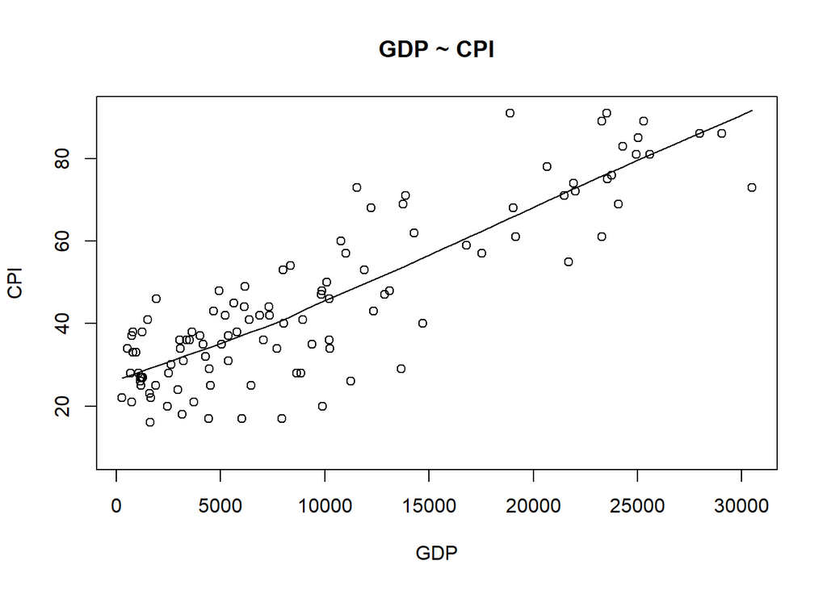

```r
scatter.smooth(x=datos_reg$gdp, y=datos_reg$cpi, main="GDP ~ CPI", xlab="GDP", ylab="CPI")
```

2. **Boxplot**: permite detectar la presencia de observaciones atípicas (outliers). Los valores atípicos pueden afectar a la predicción, modificando la dirección/pendiente de la recta de regresión.

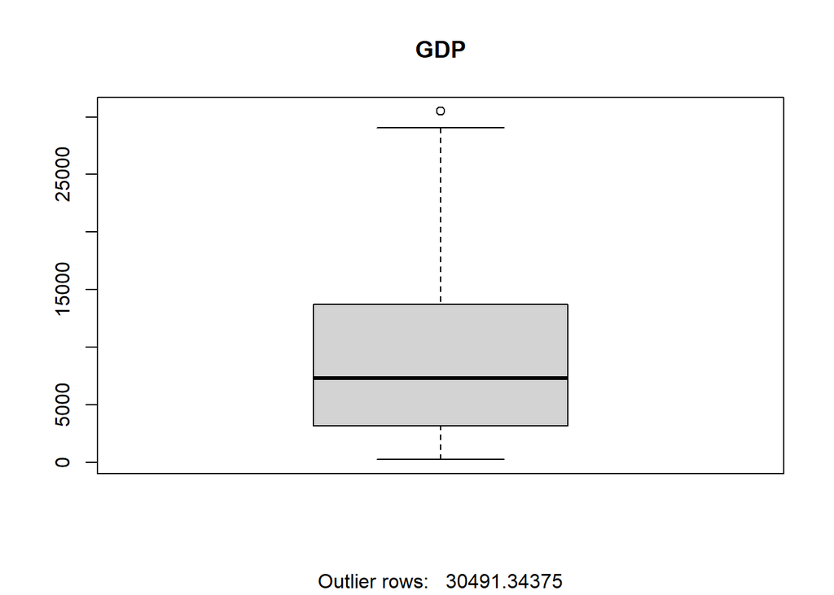

```r
boxplot(datos_reg$gdp, main="GDP", sub=paste("Outlier rows:  ", boxplot.stats(datos_reg$gdp)$out))
```

- Si se quiere comprobar con qué caso se corresponden los valores atípicos detectados se puede usar el siguiente comando:

```r
# Seleccionamos el nombre del país cuyo GDP es igual a 30491.34375
outlier_gdp <- datos_reg %>%
  filter(gdp == 30491.34375) %>%
  pull(cname)
table(outlier_gdp)
```

```
## outlier_gdp
## United States
##             1
```

3. **Diagrama de densidad**: para ver la distribución de la variable. Idealmente, la distribución ha de ser cercana a la normal. Si esto no ocurre, será necesario realizar alguna transformación en los datos empleados.

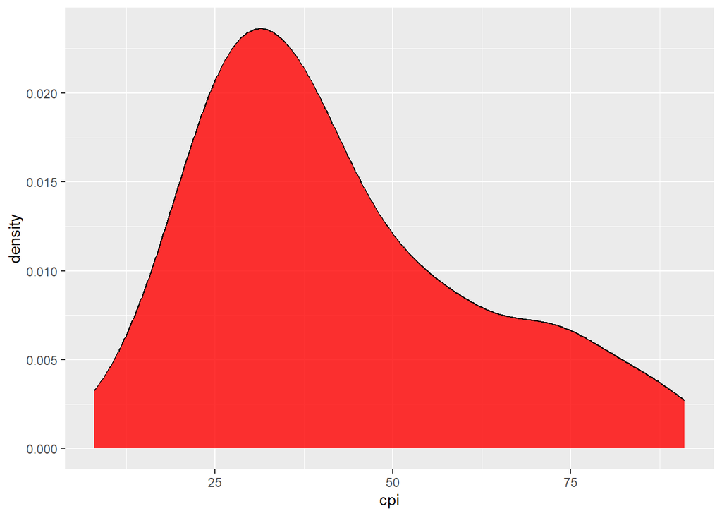

```r
ggplot(datos_reg, aes(cpi)) + geom_density(fill="red", alpha=0.8)
```

##### El modelo de regresión

La función utilizada para construir modelos lineales es `lm()` del paquete `e1071`, que toma dos argumentos principales: `lm(var_dependiente ~ var_independiente, datos)`

```r
library(e1071)
reg.lineal <- lm(cpi~gdp, data=datos_reg) #El argumento "data=" se puede omitir, basta con poner la base de datos. Es decir, se puede escribir directamente: lm(cpi~gdp, datos_reg)
reg.lineal #Conviene guardar las regresiones dentro de un objeto, ya que de otra forma no se podrían realizar los pasos posteriores.
```

```
##
## Call:
## lm(formula = cpi ~ gdp, data = datos_reg)
##
## Coefficients:
## (Intercept)          gdp
##   24.237839     0.002163
```

##### Los resultados de la regresión

Para evaluar los resultados, imprimimos las estadísticas de resumen para el modelo:

```r
summary(reg.lineal)
```

```
##
## Call:
## lm(formula = cpi ~ gdp, data = datos_reg)
##
## Residuals:
##      Min       1Q   Median       3Q      Max
## -25.5964  -5.0369   0.3185   6.4699  25.9107
##
## Coefficients:
##              Estimate Std. Error t value Pr(>|t|)
## (Intercept) 2.424e+01  1.521e+00   15.94   <2e-16 ***
## gdp         2.163e-03  1.205e-04   17.95   <2e-16 ***
## ---
## Signif. codes:  0 '***' 0.001 '**' 0.01 '*' 0.05 '.' 0.1 ' ' 1
##
## Residual standard error: 10.22 on 108 degrees of freedom
##   (84 observations deleted due to missingness)
## Multiple R-squared:  0.749,  Adjusted R-squared:  0.7467
## F-statistic: 322.3 on 1 and 108 DF,  p-value: < 2.2e-16
```

- Los **coeficientes** indican la contribución de cada variable independiente al modelo de regresión.
  - **Intercept**(β<sub>0</sub>). Establece el valor de la variable y cuando la varible x es 0 (el punto donde la recta de regresión corta la ordenada en el orígen). En el *ejemplo*, el intercepto (β0)= 24.237, lo que significa que, para un país con GDP=0, el valor de su cpi sería 24.237.
  - El *coeficiente* de la variable independiente: establece el incremento promedio que experimentará la variable dependiente (y) por cada unidad que se incremetne la variable independiente (x). En el ejemplo, el coeficiente del gdp (β1)=0.002163, lo que significa que por cada incremento de un dolar en el gdp de un país, el cpi aumenta en 0.002163 puntos.
- La evaluación de la **significatividad** de los coeficientes (βi) comienza con la definición de hipótesis sobre los valores de los parámetros poblacionales:
  - Hipótesis nula: H0: βi=0 (el valor del coeficiente en la población es 0).
  - Hipótesis alternativa: H1: βi≠0 (el valor del coeficiente en la población es distinto de 0).
  - En el summario de la regresión, se puede comprobar observando el valor de la columna con *t value* (muestra la prueba t asociada a cada β<sub>i</sub>) o el *p-valor* de la columna Pr (> | t |).
- La **bondad de ajuste** del modelo (R<sup>2</sup>) mide el porcentaje de varianza de la variable dependiente (Y) que queda explicado con nuestro modelo. Varía entre 0 y 1, y puede interpretarse como un porcentaje. Sin embargo, a medida que agregamos nuevas variables al modelo, el valor R-Squared será mayor. *Adj R-Squared* penaliza por el número de parámetros en el modelo. Por lo tanto, al comparar modelos anidados, es una buena práctica observar el valor de R<sup>2</sup> ajustado sobre R<sup>2</sup>. *En el ejemplo, podemos decir que un 74,67% de la variación en el índice de corrupción se puede explicar gracias a las diferencias en el PIB*.
- La **significatividad del modelo** (F de Snedecor). Un F estadísticamente significativo significa que al menos uno de los coficientes es estadísticamente significativo. Es decir, que nuestro modelo predice mejor que un modelo sin variables.

##### Diagnóstico de la regresión (comprobaicón de los supuestos)

1. **Linealidad**. El supuesto de linealidad puede ser comprobada con un gráfico de Residuos vs Valores Predichos.La línea horizontal, sin patrones distintivos en los puntos, indica una relación lineal.

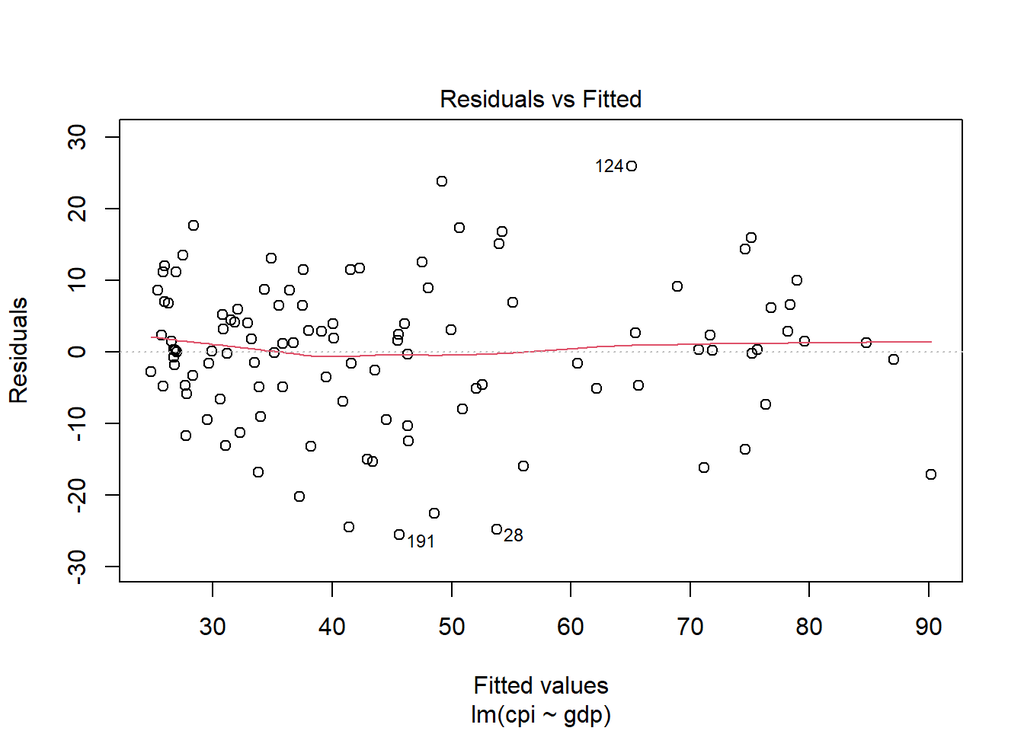

```r
plot(reg.lineal, 1)
```

2. **Normalidad de los residuos**.
1. El gráfico QQ de residuos puede usarse para comprobar visualmente el supuesto de normalidad. En este gráfico, los residuos debería seguir aproximadamente una línea recta.

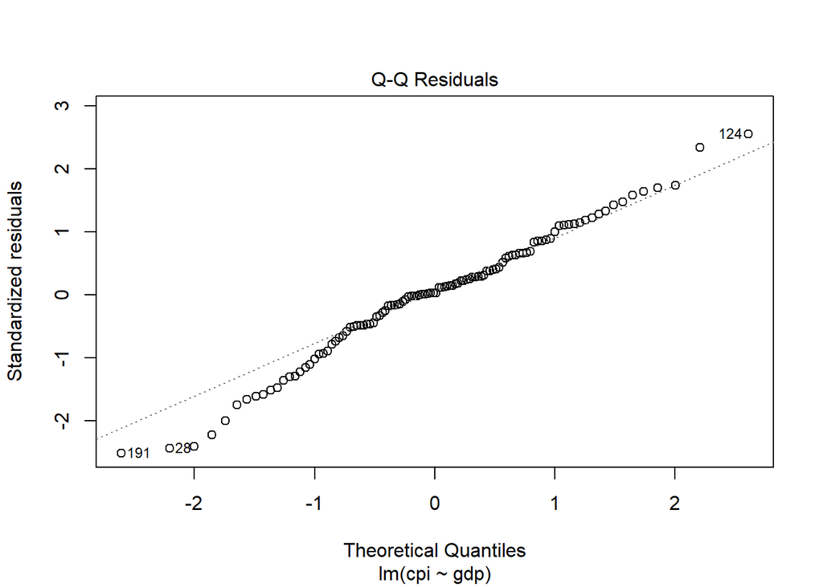

```r
plot(reg.lineal, 2)
```

2. Cuando la visualización no es clara y tenemos dudas, podemos hacer un test. Por ejemplo, el de Shapiro-Wilk. La Ho en este test es que los residuos están normalmente distribuidos (lo que queremos). El problema de este test es que está limitado a bases de datos con n menor a 5000 casos. Los resultados confirman que no podemos rechazarla.

```r
norm=rstudent(reg.lineal)
shapiro.test(norm)
```

```
##
##  Shapiro-Wilk normality test
##
## data:  norm
## W = 0.98446, p-value = 0.2316
```

Usando estos mismos datos, también se puede comprobar que la media de los residuos es igual a 0, lo que se calcula gracias a la media. Idealmente, debemos encontrar un valor muy próximo a cero.

```r
mean(reg.lineal$residuals)
```

```
## [1] -2.959911e-16
```

3. Histograma de los residuos.

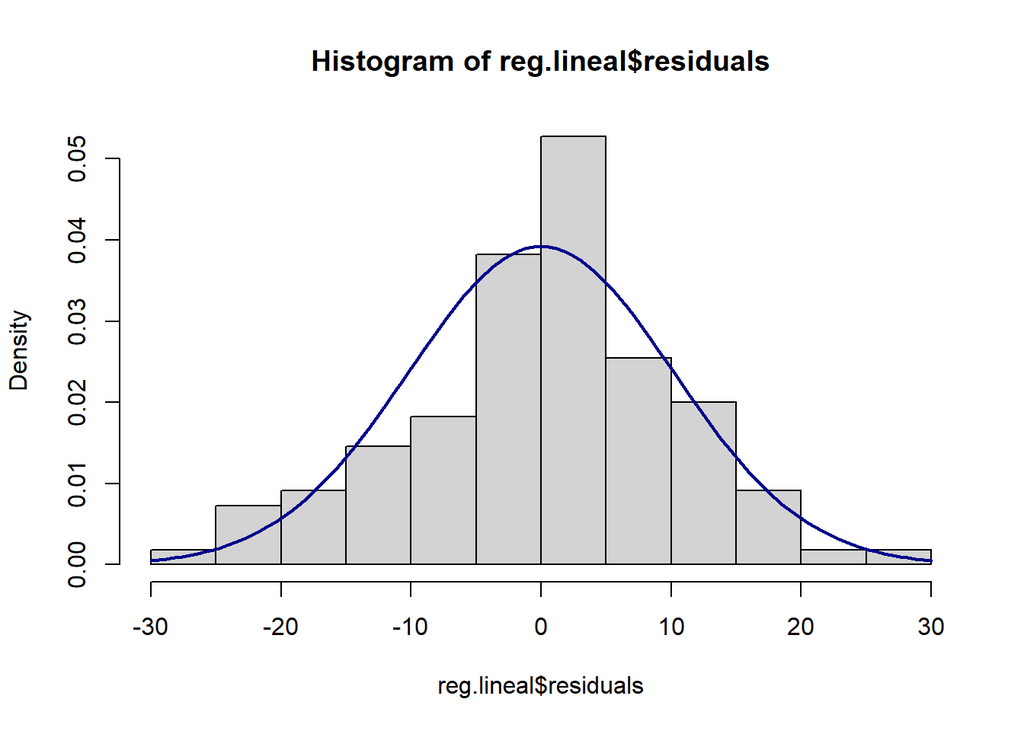

```r
hist(reg.lineal$residuals, freq = F)
# Para superponer la curva normal
m<-mean(reg.lineal$residuals)
std<-sqrt(var(reg.lineal$residuals))
curve(dnorm(x, mean=m, sd=std), col="darkblue", lwd=2, add=T)
```

*No es necesario hacer las tres opciones, sino que con elegir una es suficiente.*

3. **Homocedasticidad**.
1. Este supuesto puede comprobarse examinando el diagrama de scale-location. El gráfico muestra si los residuos se distribuyen equitativamente a lo largo de los rangos de las variables independientes. Deberíamos de observar una línea horizonal, sin fuertes tendencias.

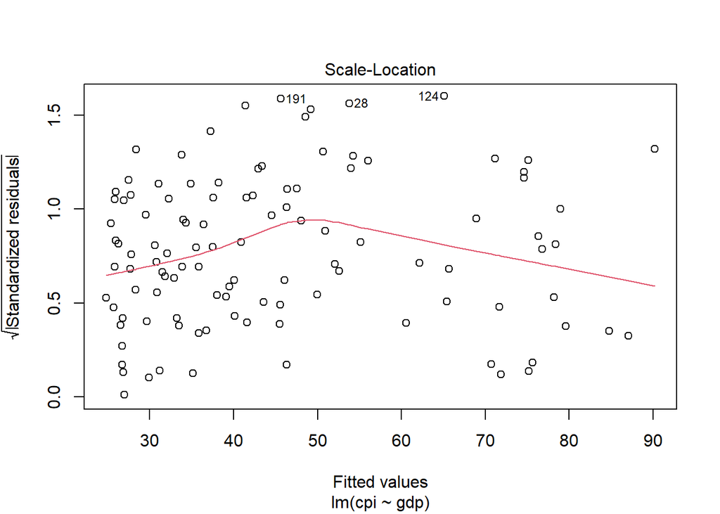

```r
plot(reg.lineal, 3)
```

ii. Para tener un resultado más concluyente, hacemos un test de heterocedasticidad. La Ho en este test es que la varianza de los residuos es constante (homocedástica, lo que queremos). La evidencia no permite rechazar la hipótesis nula, por lo cual afirmamos que la distribución es homocedástica.

```r
p_load(lmtest)
bptest(reg.lineal)
```

```
##
##  studentized Breusch-Pagan test
##
## data:  reg.lineal
## BP = 1.5496, df = 1, p-value = 0.2132
```

*Para este supuesto es mejor el test que la imágen (más dificil de interpretar)*

4. **Independencia de los residuos** Durbin Watson permite examinar si los residuos se autocorrelacionan con ellos mismos. La Ho en este test es que no están autocorrelacionados (lo que queremos). Esta prueba podría ser especialmente útil cuando tenemos series temporales (correlación serial, encuestas tipo panel). Por ejemplo, esta prueba podría decirte si los residuos en el momento T1 están correlacionados con los residuos en el momento T2 (no deberían estarlo). En los datos de sección cruzada es menos común, aunque posible (correlación espacial).

```r
p_load(car)
durbinWatsonTest(reg.lineal)
```

```
##  lag Autocorrelation D-W Statistic p-value
##    1        0.151464      1.682134    0.09
##  Alternative hypothesis: rho != 0
```

5. **Multicolinealidad**. Hace referencia a la correlación entre las VIs. Podemos medir la existencia de multicolinealidad usado el **VIF** (Variation Inflation Factor). Si el valor está por debajo de 5 está bien, no hay multicolinealidad. Por encima, si no sobrepasa demasiado esta cifra, y las variables que correlacionan son importantes para el análisis que se quiere realizar, se puede aceptar este supuesto aunque la multicolinealidad sea superior a 5.

```r
p_load(rms)
vif(reg.lineal)
```

```
## gdp
##   1
```

**Hacer los test a la vez**

1. Con la función `plot()` de R base para obtener todos los gráficos de manera conjunta.

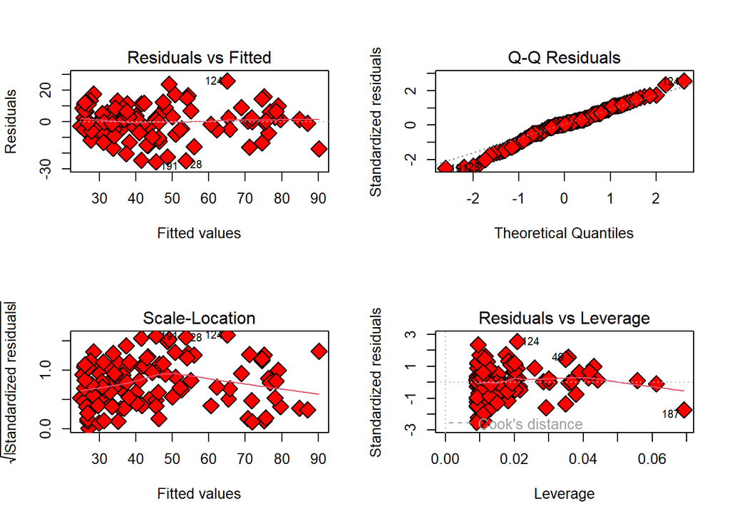

```r
par(mfrow=c(2,2))
plot(reg.lineal, pch=23 ,bg='red', cex=2)
```

Hemos visto arriba cómo interpretar gráficos 1-3. El gráfico inferior-derecha nos ayuda a detectar casos influyentes. **Leverage** es una medida de cuánta influencia ejerce cada punto la recta de regresión. No todos los valores atípicos son influyentes en el análisis de regresión lineal. Al contrario, se puede dar el caso de que haya valores extremos que no son determinantes a la hora de estima la recta de gresión, por lo que los resultados no serían muy diferentes si los excluímos del análisis. Sin embargo, si los casos están fuera de la *distancia de Cook* (lo que significa que tienen puntuaciones de distancia de Cook altas), los resultados de la regresión se alterarán si excluimos esos casos. Para un buen modelo de regresión, la línea suavizada roja debe permanecer cerca de la línea media y ningún punto debe tener una distancia de Cook grande. Si queremos identificar esos puntos en concreto (son los que se indican con un *):

```r
influence.measures(reg.lineal)
```

```
## Influence measures of
##   lm(formula = cpi ~ gdp, data = datos_reg) :
##
##        dfb.1_   dfb.gdp     dffit cov.r   cook.d     hat inf
## 2   -4.80e-02  0.024368 -5.18e-02 1.026 1.35e-03 0.01167
## 3    4.81e-02 -0.029947  4.94e-02 1.030 1.23e-03 0.01438
## 5   -6.26e-02  0.044437 -6.29e-02 1.034 1.99e-03 0.01817
## 7   -1.05e-01  0.015211 -1.46e-01 0.985 1.06e-02 0.00919
## 8   -6.88e-02 -0.008246 -1.17e-01 1.000 6.87e-03 0.00914
## 9   -1.20e-02  0.027132  3.04e-02 1.065 4.68e-04 0.04418   *
## 10   5.16e-02 -0.126716 -1.45e-01 1.048 1.06e-02 0.03792
## 12   1.36e-01 -0.072942  1.44e-01 1.000 1.03e-02 0.01223
## 13   2.22e-05 -0.000016  2.22e-05 1.038 2.49e-10 0.01891
## 14  -5.75e-02 -0.006348 -9.75e-02 1.009 4.75e-03 0.00913
## 16   1.25e-03 -0.003170 -3.67e-03 1.057 6.80e-06 0.03580   *
```

[output cut: 99 more lines]

2. Gloval Validation of Linear Models Assumptions (paquete `gvlma`).

```r
p_load(gvlma)
gvlma::gvlma(reg.lineal)
```

```
##
## Call:
## lm(formula = cpi ~ gdp, data = datos_reg)
##
## Coefficients:
## (Intercept)          gdp
##   24.237839     0.002163
##
##
## ASSESSMENT OF THE LINEAR MODEL ASSUMPTIONS
## USING THE GLOBAL TEST ON 4 DEGREES-OF-FREEDOM:
## Level of Significance =  0.05
##
## Call:
##  gvlma::gvlma(x = reg.lineal)
##
##                     Value p-value                Decision
## Global Stat        5.2691 0.26078 Assumptions acceptable.
## Skewness           1.2784 0.25819 Assumptions acceptable.
## Kurtosis           0.1015 0.75004 Assumptions acceptable.
## Link Function      0.4845 0.48641 Assumptions acceptable.
## Heteroscedasticity 3.4047 0.06501 Assumptions acceptable.
```

Concretamente:

- **Global Stat** mide si relación entre las VIs y la VD es realmente lineal. El rechazo de la Ho indica que la relación no es lineal.
- **Skewness** mide si la distribución está sesgada y necesita una transformación para cumplir con el supuesto de normalidad. El rechazo de la Ho indica que los datos deberían ser transformados.
- **Kurtosis** mide si la distribución es leptocúrtica o platicúrtica. El rechazo de la Ho indica que los datos deberían ser transformados.
- **Link Function** indica si la variable dependiente es realmente continua o es categórica. El rechazo de la Ho indica que sería conveniente usar un modelo alternativo de regresión, como el logístico o la regresión binomial.
- **Heteroscedasticity** mide el supuesto de homocedasticidad. El rechazo de la Ho indica que los residuos son heterocedásticos, y que el modelo precide unos rangos de la variable dependiente mejor que otros.

*En la práctica, lo importante es mirar los siguientes supuetos: multicolinealidad (sobre todo esta, porque se puede ver a simple vista si sabes del tema) y homocedasticidad.*

##### Exportar los resultados

Esta librería cuenta con numerosas opciones para modificar la tabla con los resultados (`?stargazer`)

```r
p_load(stargazer)
stargazer(reg.lineal,
          type="text",
          dep.var.labels=c("Corruption Perception Index"),
          covariate.labels=c("GDP","cte"))
```

```
##
## ===============================================
##                         Dependent variable:
##                     ---------------------------
##                     Corruption Perception Index
## -----------------------------------------------
## GDP                          0.002***
##                              (0.0001)
##
## cte                          24.238***
##                               (1.521)
##
## -----------------------------------------------
## Observations                    110
## R2                             0.749
## Adjusted R2                    0.747
## Residual Std. Error      10.225 (df = 108)
## F Statistic          322.340*** (df = 1; 108)
## ===============================================
## Note:               *p<0.1; **p<0.05; ***p<0.01
```

#### Teoría

**Objetivos**:

- **Estimar/predecir** los valores que adoptará la variable dependiente (VD) a partir de valores conocidos del conjunto de variables independientes (VIs).
- **Cuantificar** la relación de dependencia. Es decir, determinar qué proporción de varianza de la VD queda explicada por la suma de VIs.
- **Determinar el grado de confianza** con que se puede afirmar que la relación observada en los datos muestras se da en la población.

**Regresión lineal simple**

Cuando hacemos una regresión lineal modelamos una variable continua **y** como una función matemática de una o más variables **xi**, de manera que podamos usar ese modelo de regresión para predecir **y** cuando solo conozcamos **xi**. Hablamos de regresión simple cuando sólo están involucradas dos variables. En este caso, la ecuación de regresión se puede generalizar de la siguiente manera:

- Fórmula matemática:

$$y = \beta_1 + \beta_2 x$$

- Fórmula regresiva:

$$\hat{y} = \hat{\beta}_1 + \hat{\beta}_2
+ u$$
donde **β1** es la ordenada en el origen (o lo que es lo mismo, el valor de y cuando xi = 0) y **β2** es la pendiente de la recta. En conjunto, se denominan coeficientes de regresión. El término u es el término de error, es decir, la parte de variable dependiente que el modelo de regresión no puede explicar. Gráficamente:

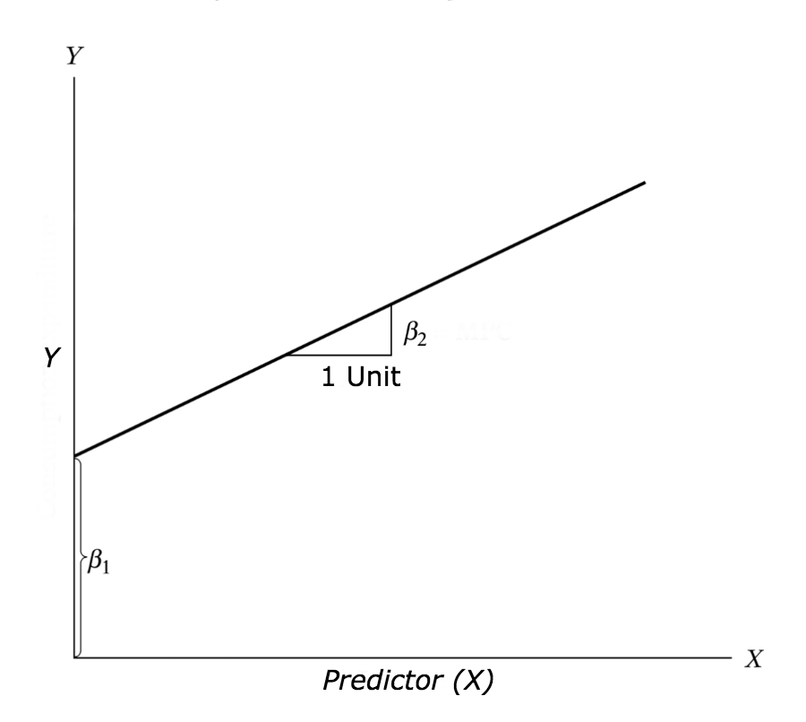

Intervalos de confianza

**Mínimos Cuadrados Ordinarios (MCO)**

Mediante la regresión lineal de una variable y sobre una variable x, buscamos una función que sea una aproximación de una nube de puntos (x<sub>i</sub>, y<sub>i</sub>). Por una nube de puntos, sin embargo, pasan infinitas rectas. Para conocer cuál es la más adecuada, se emplea el método de MCO (OLS en inglés) para estimar los parámetros del modelo (*β<sub>i</sub>*).El método de los mínimos cuadrados se utiliza para calcular la recta de regresión lineal que minimiza los residuos, esto es, las diferencias entre los valores reales observados (yi) y los valores estimados por la recta (<sub>i</sub>).

**Bondad de ajuste del modelo**

El método de mínimos cuadrados selecciona la línea que más se ajusta a nuestras observaciones. Sin embargo, que esa recta sea la mejor, no quiere decir que sea necesariamente buena. Para determinar la bondad de ajuste de nuestro modelo vamos a utilizar el Coeficiente de Determinación R<sup>2</sup>.

El coeficiente de determinación explica cuánta varianza de la variable dependiente podemos explicar con nuestro modelo. Su valor puede oscilar entre 0 y 1. Cuanto mayor sea su valor, más preciso será el modelo de regresión. A menudo se interpreta como un porcentaje.

**Supuestos de la regresión**

Para ver si un modelo de regresión lineal ajustado es válido, debemos comprobar que se cumplen estas tres condiciones sobre los residuos:

1. Independencia: los residuos deben ser independientes entre sí
2. Homocedasticidad: para cada valor de la variable x, la varianza de los residuos ei debe ser la misma (es decir, que el ajuste es igual de preciso independientemente de los valores que tome x).
3. Normalidad: para cada valor de la variable independiente x, los residuos ei se distribuyen normalmente con media 0.

Además:

4. La relación entre las variables x e y es lineal.
5. Ausencia de multicolinealidad (dos de las variables independientes están muy correlacionadas, una explica la otra).

### Lineal múltiple

Llamamos regresión lineal múltiple al análisis de regresión que incluye más de una variable independiente. Se representa como:

$$E(y) = \beta_{0} + \beta_{1}{x_{1}} + \
\beta_{12}{x_{2}} + \beta_{3}{x_{3}} + u$$

donde **β<sub>0</sub>** es el valor de *y* cuando todas las *x<sub>i</sub>* valen 0, **β<sub>i</sub>** son los coeficientes de las variables independientes y el término **u** es el término de error.

Esta ecuación definiría un hiperplano, pues con una VI se define una recta, con dos VIs un plano, con tres VIs un espacio de tres dimensiones, y así sucesivamente.

**Apartados:**

1. Preparar la base de datos (eliminar NA)
2. Modelo de regresión y resultados
3. Visualización de los coeficientes
4. Supuestos del modelo
5. Valores predichos e intervalos de confianza
6. Exportar los resultados
7. Comparación de modelos

##### Resumen de las funciones principales

```r
# Eliminar los NA de la base de datos
lista_variables <- c("var1","var2","var3"...)
datos_reg <- datos[lista_variables]
datos_reg <- na.omit(datos_Reg)

# Función de la regresión
regresión <- lm(var1~var2 + var3 + var4, datos_reg) #Librería e1071
summary(regresión)

#Visualizar los coeficientes
coefplot(regresión, xlim=c(-5, 5), col.pts="blue", intercept=TRUE, main="Coeficientes de la regresión") #Librería arm

# Comprobación de los supuestos principales
plot(regresión,2) #Normalidad de los residuos
bptest(regresión) #Homocedasticidad (librería lmtest)
vif(regresión) #Multicolinealidad (librería rms)

# Valores predichos


#Exportar los resultados
stargazer(regresión, type="text") #Librería stargazer

#Comparación de modelos
AIC(modelo1, modelo2, modelo3)
BIC(modelo1, modelo2, modelo3)
```

##### Ejemplo práctico

Vamos a estimar la propensión de voto a un partido (variable escala) en función de las siguientes variables:

- edad del entrevistado (variable continua)
- sexo (variable dicotómica)
- nivel educativo (variable dicotómica)
- opinión sobre la situación económica personal (variable dicotómica)
- opinión sobre la situación económica en España (variable dicotómica)
- recuerdo de voto (variable politómica)
- ideología del entrevistado (variable escala)

Es posible que estas variables no configuren un buen modelo. Sin embargo, son un buen ejercicio porque nos permitirá ver cómo se interpretan los diferentes tipos de variables e identificar algunos problemas.

##### Preparar la base de datos

La regresión lineal es “sensible” a la existencia de casos perdidos en las variables que se introducen en los modelos. Para evitar que diferentes modelos tengan diferentes número de casos **(en cuyo caso no serían comparables)** creamos un nuevo data.frame que contenga únicamente las columnas que vamos a usar para estimar los modelos, para eliminar de estos los casos perdidos. A continuación, eliminamos todas las filas que continenen valores perdidos. Esto se hace usando la funciones `na.omit()` o `na.exclude()`.

```r
myvars <- c("prop_psoe", "prop_pp", "edad", "hombre", "recuerdo19", "estudios_universitarios", "ideol", "ecoper", "ecoesp")   # nuevo data.frame
datos_red<-datos[myvars] #Los corchetes sirven para seleccionar solo el conjunto de datos especificado. También podría usarse la función select.
datos_red<- na.omit(datos_red)
```

##### El modelo de regresión

A continuación, esitmamos el modelo de regresión (modelPP) con las variables arriba especificadas. Usaremos la función `lm()` de la libería *e1071* (como ocurre siempre, existen muchas otras librerías que incluyen funciones para estimar regresiones lineales y son igualmente válidas).

```r
library(e1071)

modelPP <- lm(prop_pp ~ edad + hombre + estudios_universitarios + ecoper + ecoesp + recuerdo19 + ideol, data=datos_red)
summary(modelPP)
```

```
##
## Call:
## lm(formula = prop_pp ~ edad + hombre + estudios_universitarios +
##     ecoper + ecoesp + recuerdo19 + ideol, data = datos_red)
##
## Residuals:
##     Min      1Q  Median      3Q     Max
## -9.6522 -1.4692 -0.2591  1.5518  9.8268
##
## Coefficients:
##                                Estimate Std. Error t value Pr(>|t|)
## (Intercept)                    0.764501   0.082283   9.291  < 2e-16 ***
## edad                          -0.000385   0.001114  -0.346 0.729637
## hombreHombre                  -0.045523   0.033180  -1.372 0.170080
## estudios_universitarioscon EU  0.120337   0.034416   3.497 0.000472 ***
## ecoperpositiva                 0.173926   0.038775   4.485 7.31e-06 ***
## ecoesppositiva                -0.729276   0.038624 -18.881  < 2e-16 ***
## recuerdo19PP                   4.149196   0.055763  74.407  < 2e-16 ***
## recuerdo19VOX                  0.580711   0.075540   7.687 1.56e-14 ***
## recuerdo19Podemos             -0.969983   0.056628 -17.129  < 2e-16 ***
## recuerdo19Ciudadanos           2.837302   0.068713  41.292  < 2e-16 ***
## recuerdo19Más Madrid          -0.554132   0.189993  -2.917 0.003542 **
## recuerdo19Otros               -1.012513   0.052845 -19.160  < 2e-16 ***
## recuerdo19En blanco            0.666554   0.139864   4.766 1.89e-06 ***
## ideol                          0.445504   0.008478  52.549  < 2e-16 ***
## ---
## Signif. codes:  0 '***' 0.001 '**' 0.01 '*' 0.05 '.' 0.1 ' ' 1
##
## Residual standard error: 2.473 on 22880 degrees of freedom
## Multiple R-squared:  0.5873, Adjusted R-squared:  0.5871
## F-statistic:  2505 on 13 and 22880 DF,  p-value: < 2.2e-16
```

Como podemos observar, R transforma la variable politómica “recuerdo19” en c-1 variables. Lo hace porque está definida como factor, de lo contrario trataría la variable como numérica (lo cual no tendría ningún sentido). En este caso, cada variable se interpreta **en relación a la categoría de refencia** (en este caso, PSOE). La función `relevel()` nos permite cambiar cambiar la categoría de referencia. Por ejemplo, si queremos que “PP” sea nuestra categoría de referencia, haríamos lo siguiente:

```r
modelPP_newrc<- lm(prop_pp ~ edad + hombre + estudios_universitarios + ecoper + ecoesp +relevel(recuerdo19, ref ="PP") + ideol, data=datos_red)
summary(modelPP_newrc)
```

**Significatividad del modelo**

##### Interpretación de los coeficientes

Más allá de la significación estadística, es importante interpretar el tamaño del coeficiente. En otras palabras, la magnitud del efecto. En regresión lineal múltiple, los coeficientes de regresión representan el **cambio promedio que se produce en la VD por cada unidad de cambio en la VI, mientras el resto de variables se mantiene constante** (*ceteris paribus*). Este control estadístico que proporciona la regresión es muy importante, porque aisla el efecto de una variable del resto de variable incluidas en el modelo.

El valor de los coeficientes se obtiene con la función `sumary()` del modelo, y también puede extraerse fácilmente de la lista *modelPP* (ver función `View(modelPP)`)

```r
modelPP$coefficients
```

```
##                   (Intercept)                          edad
##                  0.7645004705                 -0.0003850228
##                  hombreHombre estudios_universitarioscon EU
##                 -0.0455226223                  0.1203369895
##                ecoperpositiva                ecoesppositiva
##                  0.1739256464                 -0.7292760576
##                  recuerdo19PP                 recuerdo19VOX
##                  4.1491958693                  0.5807105360
##             recuerdo19Podemos          recuerdo19Ciudadanos
##                 -0.9699832612                  2.8373014511
##          recuerdo19Más Madrid               recuerdo19Otros
##                 -0.5541319048                 -1.0125132971
##           recuerdo19En blanco                         ideol
##                  0.6665536962                  0.4455040602
```

Vamos a ver algunos ejemplos:

- El *coeficiente de estudios_universitarioscon_ES* (0.1203) indica que, manteniendo constantes todas las demás variables, tener estudios universitarios está asociado con un aumento de 0.1203 unidades en la propensión de voto al Partido Popular. En otras palabras, las personas con estudios universitarios tienen, en promedio, una mayor inclinación a votar por el Partido Popular en comparación con aquellas que no tienen estudios universitario (*ceteris paribus*)
- El *coeficiente de recuerdo19PP* (4.149) indica que, manteniendo constantes todas las demás variables, las personas que recuerdan haber votado al Partido Popular en las elecciones de 2019 tienen una propensión de voto al Partido Popular 4.149 unidades mayor en comparación con aquellas que recuerdan haber votado al PSOE (la categoría de referencia). Esto significa que, en términos de propensión al voto, el recuerdo de haber votado al PP en el pasado está fuertemente asociado con una mayor inclinación a votar nuevamente por este partido, mucho más que en comparación con aquellos que votaron al PSOE (*ceteris paribus*)

**Visualizacion de los coeficientes**

Una manera rápida de presentar los resultados de la regresión es representar gráficamente los coeficientes. Para ello, podemos usar la función `coefplot()`

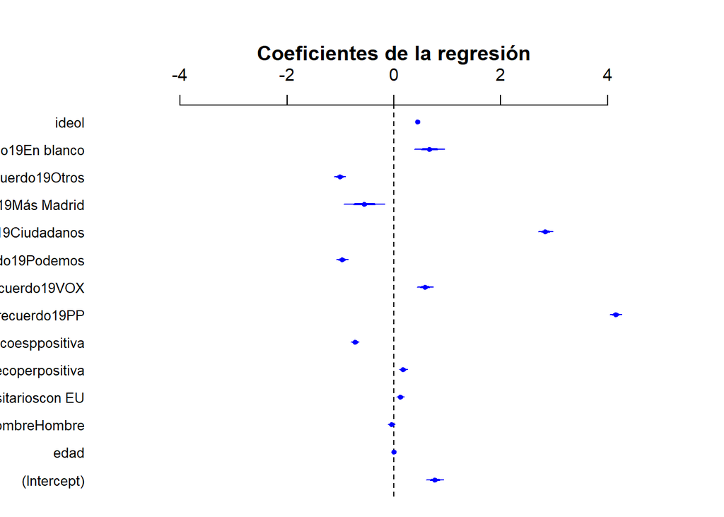

```r
p_load(arm)
coefplot(modelPP, xlim=c(-5, 5),col.pts="blue", intercept=TRUE, main="Coeficientes de la regresión")
```

Este tipo de gráfico es particularmente útil cuando queremos **comparar los coeficientes de dos o más modelos**. Por ejemplo, si calculamos el mismo modelo para estimar la propensión de voto al PSOE, podemos visualizar los coeficientes de ambos modelos de la siguiente manera

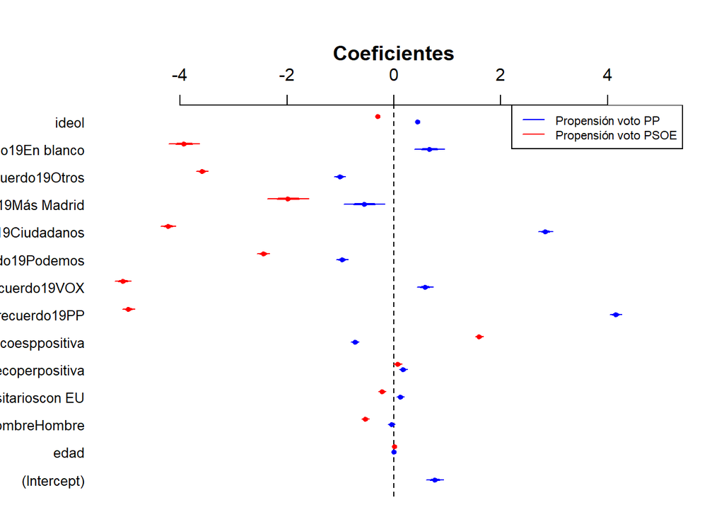

```r
#Estimamos el modelo
modelPSOE <- lm(prop_psoe ~ edad + hombre + estudios_universitarios + ecoper + ecoesp + recuerdo19 + ideol, data=datos_red)

#Representamos gráficamente los coeficientes de ambas regresiones (argumento add=T)
par(mfrow = c(1,1))
coefplot(modelPP, xlim=c(-5, 5),col.pts="blue", intercept=TRUE, main="Coeficientes")
coefplot(modelPSOE, add=TRUE, col.pts="red",  intercept=TRUE, offset=0.2, main="PSOE")

#Añadimos leyenda
legend("topright",
       c("Propensión voto PP", "Propensión voto PSOE"),
       lty = c(1,1),
       col=c("blue","red"),
       cex = 0.7)
```

**¿Qué variable es la más importante?**

Dado que las variables están expresadas en diferentes unidades, los coeficientes de la regresión no son directamente comparables entre sí. Para hacer esto posible, es necesario transformar dichos coeficientes en coeficientes estandarizados (coeficientes Beta). Los coeficientes estandarizados se basan en puntuaciones típicas y, por lo tanto, son comparables entre sí.

```r
p_load(lm.beta)
betaPP<-lm.beta(modelPP)
summary(betaPP)
```

```
##
## Call:
## lm(formula = prop_pp ~ edad + hombre + estudios_universitarios +
##     ecoper + ecoesp + recuerdo19 + ideol, data = datos_red)
##
## Residuals:
##     Min      1Q  Median      3Q     Max
## -9.6522 -1.4692 -0.2591  1.5518  9.8268
##
## Coefficients:
##                                Estimate Standardized Std. Error t value
## (Intercept)                    0.764501           NA   0.082283   9.291
## edad                          -0.000385    -0.001541   0.001114  -0.346
## hombreHombre                  -0.045523    -0.005909   0.033180  -1.372
## estudios_universitarioscon EU  0.120337     0.015627   0.034416   3.497
## ecoperpositiva                 0.173926     0.020009   0.038775   4.485
## ecoesppositiva                -0.729276    -0.091072   0.038624 -18.881
## recuerdo19PP                   4.149196     0.442365   0.055763  74.407
## recuerdo19VOX                  0.580711     0.040263   0.075540   7.687
## recuerdo19Podemos             -0.969983    -0.080576   0.056628 -17.129
## recuerdo19Ciudadanos           2.837302     0.197182   0.068713  41.292
## recuerdo19Más Madrid          -0.554132    -0.012506   0.189993  -2.917
## recuerdo19Otros               -1.012513    -0.089720   0.052845 -19.160
## recuerdo19En blanco            0.666554     0.020676   0.139864   4.766
## ideol                          0.445504     0.310399   0.008478  52.549
##                               Pr(>|t|)
## (Intercept)                    < 2e-16 ***
## edad                          0.729637
## hombreHombre                  0.170080
## estudios_universitarioscon EU 0.000472 ***
## ecoperpositiva                7.31e-06 ***
## ecoesppositiva                 < 2e-16 ***
## recuerdo19PP                   < 2e-16 ***
## recuerdo19VOX                 1.56e-14 ***
## recuerdo19Podemos              < 2e-16 ***
## recuerdo19Ciudadanos           < 2e-16 ***
## recuerdo19Más Madrid          0.003542 **
## recuerdo19Otros                < 2e-16 ***
## recuerdo19En blanco           1.89e-06 ***
## ideol                          < 2e-16 ***
## ---
## Signif. codes:  0 '***' 0.001 '**' 0.01 '*' 0.05 '.' 0.1 ' ' 1
##
## Residual standard error: 2.473 on 22880 degrees of freedom
## Multiple R-squared:  0.5873, Adjusted R-squared:  0.5871
## F-statistic:  2505 on 13 and 22880 DF,  p-value: < 2.2e-16
```

Los coeficientes estandarizados representan la cantidad de cambio, en unidades de desviación estándar, que se producirá en la variable dependiente por cada aumento de una unidad de desviación estándar en la correspondiente variable independiente (manteniendo constantes las demás variables). Al estandarizar las variables, la constante se iguala a 0, por lo que no se incluye en la ecuación de predicción. Estos coeficientes indican la importancia relativa de cada variable independiente en la ecuación de regresión. En general, cuanto mayor es el valor absoluto del coeficiente de regresión estandarizado, mayor es el peso de la variable en la ecuación de regresión.

**Bondad de ajuste del modelo** El R<sup>2</sup> tiene un valor de 0.5873, lo que indica que nuestro modelo explica el 58.73% de varianza de la VD. En este caso, el valor de R<sup>2</sup> ajustado es prácticamente idéntico.

##### Diagnóstico de la regresión

Vamos a comprobar los supuestos de la regresión

1. *Normalidad de los residuos*. El test de normalidad que usamos en el ejemplo de regresión simple (*Shapiro test*) está limitado a n=5000. Dado que no tenemos esa opción, vamos a revisar el supuesto de normalidad un gráfico Q-Q:

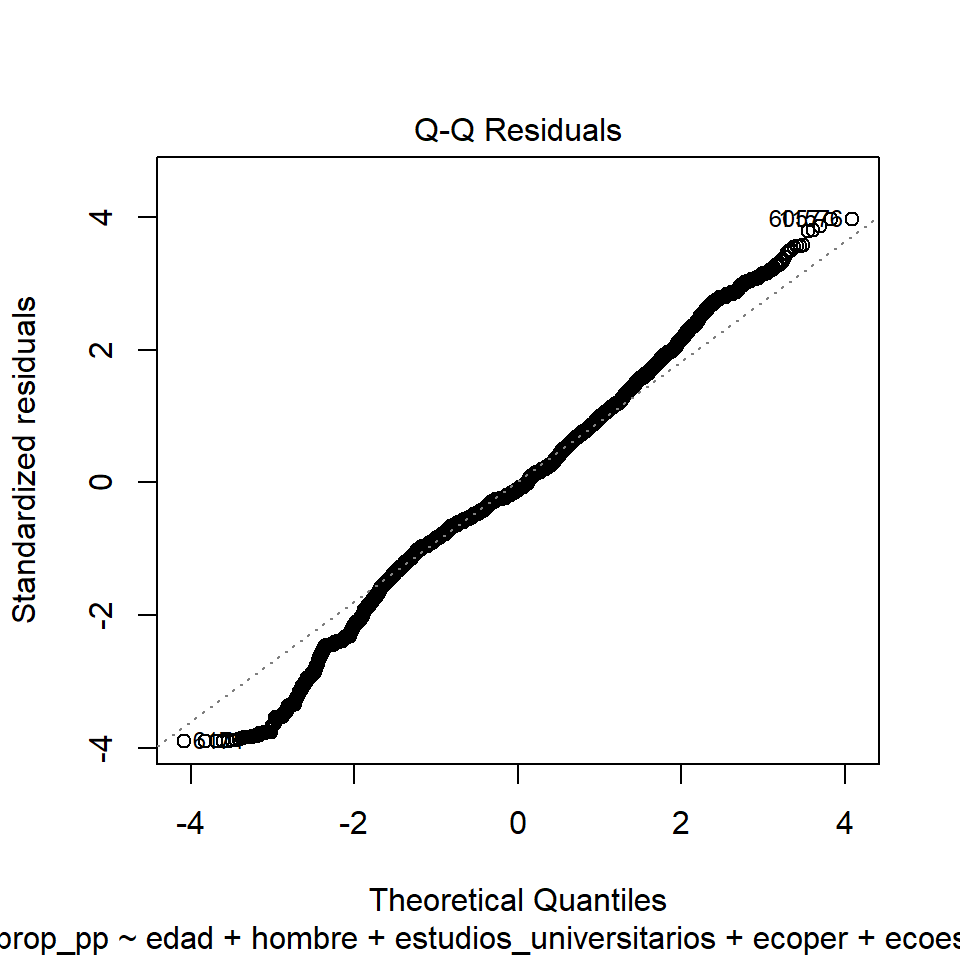

```r
plot(modelPP, 2)
```

Comprobamos también que la media de los residuos=0

```r
mean(modelPP$residuals)
```

```
## [1] -2.04219e-16
```

2. *Homocedasticidad* (varianza constante de los residuos)
- Test de homocedasticidad

```r
#install.packages("lmtest")
library(lmtest)
het.lm<-bptest(modelPP)
het.lm
```

```
##
##  studentized Breusch-Pagan test
##
## data:  modelPP
## BP = 2557.5, df = 13, p-value < 2.2e-16
```

La hipótesis nula en este test es que la varianza de los residuos es constante (homocedástica). La evidencia permite rechazar la hipótesis nula, confirmando que la distribución es heterocedástica (no se cumple el suspuesto). La distrivución de los residuos no es constante.

- Gráficamente:

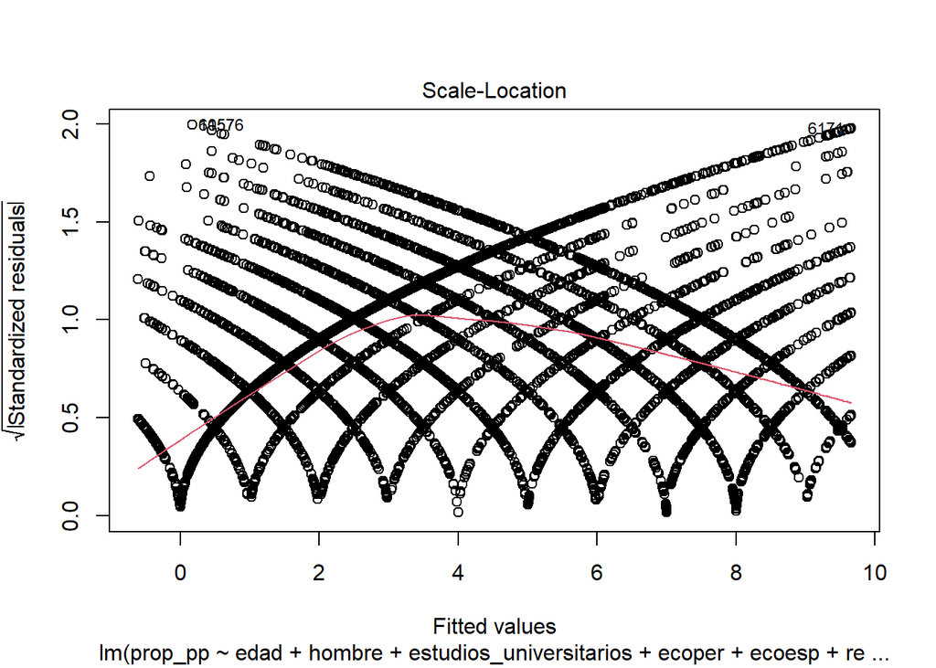

```r
plot( modelPP, 3)
```

3. *Multicolinealidad*.

```r
reg.lineal.vif <- car::vif(modelPP)
reg.lineal.vif
```

```
##                             GVIF Df GVIF^(1/(2*Df))
## edad                    1.102517  1        1.050008
## hombre                  1.028258  1        1.014030
## estudios_universitarios 1.107391  1        1.052327
## ecoper                  1.103228  1        1.050347
## ecoesp                  1.289873  1        1.135726
## recuerdo19              2.198730  7        1.057891
## ideol                   1.934408  1        1.390830
```

No parece que existan problemas de multicolinealidad en nuestro modelo.

##### Valores predichos

Al igual que hicimos con los coeficientes, una vez calculado el modelo podemos extraer los valores predichos (estimados) para cada individuo en la muestra consultando `modelPP$fitted.values`. Esto nos permite, por ejemplo, calcular el valor medio de propensión de voto al PP:

```r
mean(modelPP$fitted.values)
```

```
## [1] 3.678606
```

```r
data1 <- data.frame(hombre="Hombre", edad=50, estudios_universitarios="con EU", ecoper="positiva", ecoesp="negativa", ideol=5, recuerdo19="Ciudadanos")
yhat1<-predict(modelPP, newdata = data1)
yhat1
```

```
##        1
## 6.058811
```

O calcular, por ejemplo, cómo cambia la propensión de voto al PP para un individuo con esas mismas características en función de su edad:

```r
data2<- data.frame(hombre="Hombre", edad=c(20, 30, 40, 50, 60, 70, 80), estudios_universitarios="con EU", ecoper="positiva", ecoesp="negativa", ideol=5, recuerdo19="Ciudadanos")
yhat2<-predict(modelPP, newdata = data2)
yhat2
```

```
##        1        2        3        4        5        6        7
## 6.070362 6.066512 6.062661 6.058811 6.054961 6.051111 6.047260
```

**Intervalos de confianza**

Los intervalos de confianza reflejan la incertidumbre alrededor de las estimaciones medias. Siguiendo con el ejemplo anterior, vamos a calcular las probabilides predichas con sus intervalos de confianza para todos los individuos en la muestra (*fit es el valor predicho*):

```r
yhat<-predict(modelPP, newdata = datos_red, interval = "confidence")
head(yhat) #visualizamos los 5 primeros casos
```

```
##         fit       lwr       upr
## 1 7.0760579 6.9727774 7.1793383
## 2 8.1922896 8.0917476 8.2928316
## 3 8.0114335 7.9169740 8.1058930
## 4 0.5837394 0.4690074 0.6984715
## 5 3.6770243 3.5669840 3.7870646
## 6 1.9297500 1.8417350 2.0177651
```

Si no queremos ver los casos perdidos usamos el argumento *na.action* para especificarlo

```r
yhat<-predict(modelPP, newdata = datos_red, interval = "confidence", na.action=na.exclude)
head(yhat)
```

```
##         fit       lwr       upr
## 1 7.0760579 6.9727774 7.1793383
## 2 8.1922896 8.0917476 8.2928316
## 3 8.0114335 7.9169740 8.1058930
## 4 0.5837394 0.4690074 0.6984715
## 5 3.6770243 3.5669840 3.7870646
## 6 1.9297500 1.8417350 2.0177651
```

El *output* contiene 3 columnas:

- FIT: el valor predicho (que también habíamos consultado a través de `modelPP$fitted.values`)
- LWR: límite inferior de la banda de confianza
- UPR: límite superior de la banda de confianza

Por defecto, R produce bandas de confianza al 95%, pero esto se puede cambiar con el argumento *level*

```r
yhat<-predict(modelPP, newdata = datos_red, interval = "confidence", na.action=na.exclude, level=0.99)
head(yhat)
```

```
##         fit       lwr       upr
## 1 7.0760579 6.9403202 7.2117955
## 2 8.1922896 8.0601510 8.3244282
## 3 8.0114335 7.8872889 8.1355781
## 4 0.5837394 0.4329514 0.7345275
## 5 3.6770243 3.5324024 3.8216462
## 6 1.9297500 1.8140751 2.0454250
```

##### Exportar resultados

Vamos a exportar a formato científico los dos modelos que hemos estimado: modelPP y modelPSOE

**Librería stargazer**

```r
#install.packages("stargazer")
library(stargazer)
stargazer(modelPP, modelPSOE,      #Incluir aquí Modelo1, Modelo2, M3...
          type="text",
          dep.var.labels=c("Propensión voto PP", "Propensión voto PSOE"),
          covariate.labels=c("Edad", "Hombre", "Estudios superiores", "Economia personal: positiva (cr:neg)", "Economia país: positiva (cr:neg)", "Voto 2019:PP (cr: PSOE)", "Voto 2019:VOX (cr: PSOE)", "Voto 2019:Podemos (cr: PSOE)", "Voto 2019:C´s (cr: PSOE)", "Voto 2019:Más Madrid (cr: PSOE)", "Voto 2019:Otros (cr: PSOE)", "Voto 2019:Blanco (cr: PSOE)", "Ideología", "Constante"))
```

```
##
## ============================================================================
##                                                Dependent variable:
##                                      ---------------------------------------
##                                      Propensión voto PP Propensión voto PSOE
##                                             (1)                 (2)
## ----------------------------------------------------------------------------
## Edad                                      -0.0004             0.011***
##                                           (0.001)             (0.001)
##
## Hombre                                     -0.046            -0.536***
##                                           (0.033)             (0.034)
##
## Estudios superiores                       0.120***           -0.220***
##                                           (0.034)             (0.035)
##
## Economia personal: positiva (cr:neg)      0.174***             0.073*
##                                           (0.039)             (0.040)
##
## Economia país: positiva (cr:neg)         -0.729***            1.597***
##                                           (0.039)             (0.040)
##
## Voto 2019:PP (cr: PSOE)                   4.149***           -4.966***
##                                           (0.056)             (0.057)
##
## Voto 2019:VOX (cr: PSOE)                  0.581***           -5.070***
##                                           (0.076)             (0.077)
##
## Voto 2019:Podemos (cr: PSOE)             -0.970***           -2.444***
##                                           (0.057)             (0.058)
##
## Voto 2019:C´s (cr: PSOE)                  2.837***           -4.226***
##                                           (0.069)             (0.070)
##
## Voto 2019:Más Madrid (cr: PSOE)          -0.554***           -1.982***
##                                           (0.190)             (0.195)
##
## Voto 2019:Otros (cr: PSOE)               -1.013***           -3.589***
##                                           (0.053)             (0.054)
##
## Voto 2019:Blanco (cr: PSOE)               0.667***           -3.927***
##                                           (0.140)             (0.143)
##
## Ideología                                 0.446***           -0.305***
##                                           (0.008)             (0.009)
##
## Constante                                 0.765***            7.650***
##                                           (0.082)             (0.084)
##
## ----------------------------------------------------------------------------
## Observations                               22,894              22,894
## R2                                         0.587               0.593
## Adjusted R2                                0.587               0.592
## Residual Std. Error (df = 22880)           2.473               2.532
## F Statistic (df = 13; 22880)            2,504.777***        2,560.708***
## ============================================================================
## Note:                                            *p<0.1; **p<0.05; ***p<0.01
```

**Librería jtools**. Está disponible únicamente para un tipo de modelos muy limitado, pero OLS y GLM están incluidos.

Instalamos los paquetes que van a hacernos falta

```r
p_load(jtools, ggstance, huxtable)
```

La función `summ()` muestra los resultados de la regresión

```r
summ(modelPP)
```

```
## MODEL INFO:
## Observations: 22894
## Dependent Variable: prop_pp
## Type: OLS linear regression
##
## MODEL FIT:
## F(13,22880) = 2504.78, p = 0.00
## R² = 0.59
## Adj. R² = 0.59
##
## Standard errors:OLS
## -------------------------------------------------------------
##                                   Est.   S.E.   t val.      p
## ------------------------------ ------- ------ -------- ------
## (Intercept)                       0.76   0.08     9.29   0.00
## edad                             -0.00   0.00    -0.35   0.73
## hombreHombre                     -0.05   0.03    -1.37   0.17
## estudios_universitarioscon        0.12   0.03     3.50   0.00
## EU
## ecoperpositiva                    0.17   0.04     4.49   0.00
## ecoesppositiva                   -0.73   0.04   -18.88   0.00
## recuerdo19PP                      4.15   0.06    74.41   0.00
## recuerdo19VOX                     0.58   0.08     7.69   0.00
## recuerdo19Podemos                -0.97   0.06   -17.13   0.00
## recuerdo19Ciudadanos              2.84   0.07    41.29   0.00
## recuerdo19Más Madrid             -0.55   0.19    -2.92   0.00
## recuerdo19Otros                  -1.01   0.05   -19.16   0.00
## recuerdo19En blanco               0.67   0.14     4.77   0.00
## ideol                             0.45   0.01    52.55   0.00
## -------------------------------------------------------------
```

La representación gráfica de los coeficientes también se hace de manera muy sencilla y muy parecida a la que ya conocemos

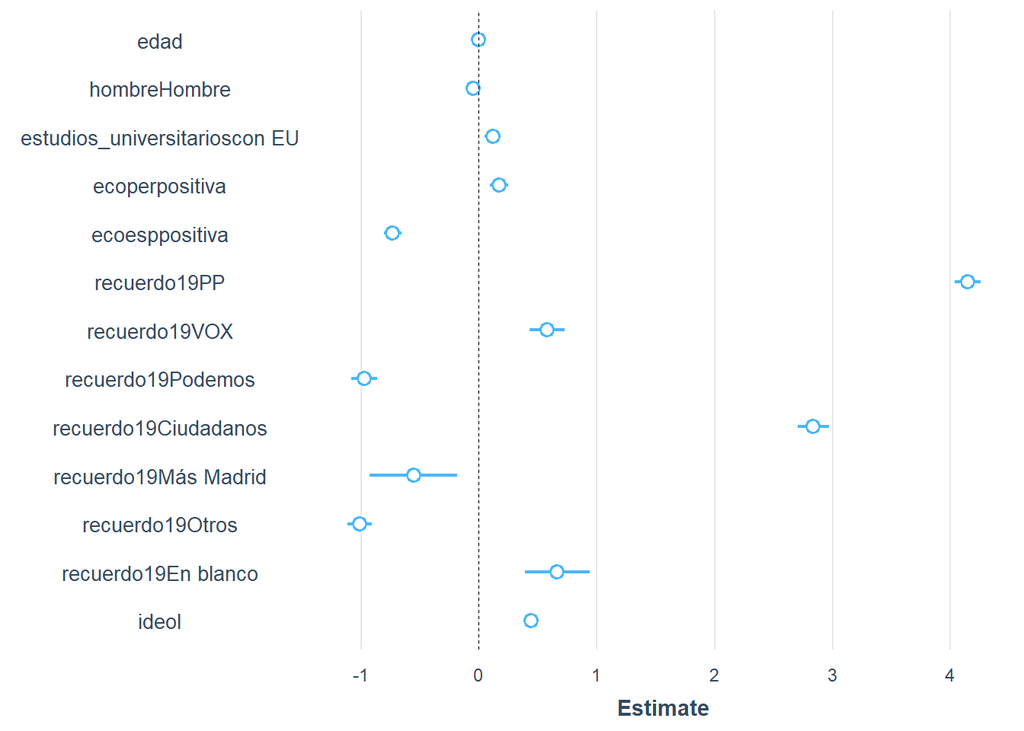

```r
plot_summs(modelPP)
```

Se pueden añadir tantos modelos como deseemos

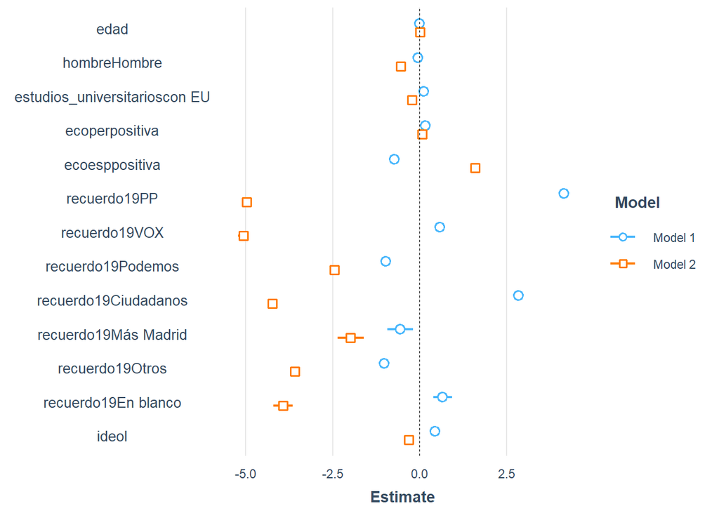

```r
plot_summs(modelPP, modelPSOE)
```

También permite visualizar de manera rápida el efecto de una variable sobre la variable dependiente, siempre que la primera sea continua. Por ejemplo, vamos cómo varía la propensión de votar al PP con la ideología, controlado por el resto de variables

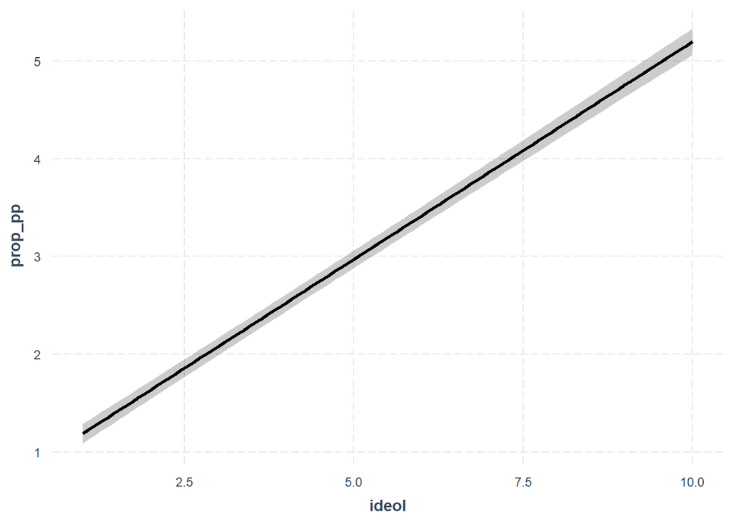

```r
effect_plot(modelPP, pred = ideol, interval = TRUE)
```

Finalmente, la función export_summs de jtools permite representar las tablas en formato “científico”.

```r
export_summs(modelPP, modelPSOE)
```

|  | Model 1 | Model 2 |
| --- | --- | --- |
| (Intercept) | 0.76 *** | 7.65 *** |
|  | (0.08) | (0.08) |
| edad | -0.00 | 0.01 *** |
|  | (0.00) | (0.00) |
| hombreHombre | -0.05 | -0.54 *** |
|  | (0.03) | (0.03) |
| estudios_universitarioscon EU | 0.12 *** | -0.22 *** |
|  | (0.03) | (0.04) |
| ecoperpositiva | 0.17 *** | 0.07 |
|  | (0.04) | (0.04) |
| ecoesppositiva | -0.73 *** | 1.60 *** |
|  | (0.04) | (0.04) |
| recuerdo19PP | 4.15 *** | -4.97 *** |
|  | (0.06) | (0.06) |
| recuerdo19VOX | 0.58 *** | -5.07 *** |
|  | (0.08) | (0.08) |
| recuerdo19Podemos | -0.97 *** | -2.44 *** |
|  | (0.06) | (0.06) |
| recuerdo19Ciudadanos | 2.84 *** | -4.23 *** |
|  | (0.07) | (0.07) |
| recuerdo19Más Madrid | -0.55 ** | -1.98 *** |
|  | (0.19) | (0.19) |
| recuerdo19Otros | -1.01 *** | -3.59 *** |
|  | (0.05) | (0.05) |
| recuerdo19En blanco | 0.67 *** | -3.93 *** |
|  | (0.14) | (0.14) |
| ideol | 0.45 *** | -0.31 *** |
|  | (0.01) | (0.01) |
| N | 22894 | 22894 |
| R2 | 0.59 | 0.59 |
| *** p < 0.001; ** p < 0.01; * p < 0.05. |  |  |

Para renombrar los modelos y las variables, usaremos los argumentos model.names y coefs de la siguiente manera

```r
export_summs(modelPP, modelPSOE,
  model.names=c("Prop. Voto PP",
                "Prop. Voto PSOE"),
  coefs=c("Edad"="edad",
          "Hombre"="hombreHombre",
          "Estudios Universitarios"="estudios_universitarioscon EU",
          "Economía personal positiva (cr=neg)"="ecoperpositiva",
          "Economía país positiva (cr=neg)"="ecoesppositiva",
          "Voto 2019:PP (cr=PSOE)"="recuerdo19PP",
          "Voto 2019:VOX (cr=PSOE)"="recuerdo19VOX",
          "Voto 2019:Podemos (cr=PSOE)"="recuerdo19Podemos",
          "Voto 2019:C´s (cr=PSOE)"="recuerdo19Ciudadanos",
          "Voto 2019:Mas País (cr=PSOE)"="recuerdo19Más Madrid",
          "Voto 2019:Otros (cr=PSOE)"="recuerdo19Otros",
          "Voto 2019:Blanco (cr=PSOE)"="recuerdo19En blanco",
          "Ideología"="ideol",
          "Constante"="(Intercept)"
))
```

|  | Prop. Voto PP | Prop. Voto PSOE |
| --- | --- | --- |
| Edad | -0.00 | 0.01 *** |
|  | (0.00) | (0.00) |
| Hombre | -0.05 | -0.54 *** |
|  | (0.03) | (0.03) |
| Estudios Universitarios | 0.12 *** | -0.22 *** |
|  | (0.03) | (0.04) |
| Economía personal positiva (cr=neg) | 0.17 *** | 0.07 |
|  | (0.04) | (0.04) |
| Economía país positiva (cr=neg) | -0.73 *** | 1.60 *** |
|  | (0.04) | (0.04) |
| Voto 2019:PP (cr=PSOE) | 4.15 *** | -4.97 *** |
|  | (0.06) | (0.06) |
| Voto 2019:VOX (cr=PSOE) | 0.58 *** | -5.07 *** |
|  | (0.08) | (0.08) |
| Voto 2019:Podemos (cr=PSOE) | -0.97 *** | -2.44 *** |
|  | (0.06) | (0.06) |
| Voto 2019:C´s (cr=PSOE) | 2.84 *** | -4.23 *** |
|  | (0.07) | (0.07) |
| Voto 2019:Mas País (cr=PSOE) | -0.55 ** | -1.98 *** |
|  | (0.19) | (0.19) |
| Voto 2019:Otros (cr=PSOE) | -1.01 *** | -3.59 *** |
|  | (0.05) | (0.05) |
| Voto 2019:Blanco (cr=PSOE) | 0.67 *** | -3.93 *** |
|  | (0.14) | (0.14) |
| Ideología | 0.45 *** | -0.31 *** |
|  | (0.01) | (0.01) |
| Constante | 0.76 *** | 7.65 *** |
|  | (0.08) | (0.08) |
| N | 22894 | 22894 |
| R2 | 0.59 | 0.59 |
| *** p < 0.001; ** p < 0.01; * p < 0.05. |  |  |

##### Comparación de modelos

Es muy frecuente tener que elegir entre diferentes modelos. Hasta ahora, nos hemos fijado en el R<sup>2</sup> para ver cuál era la bondad de ajuste del modelo. Aquí, vamos a introducir dos nuevos indicadores: **BIC** (Criterio de Información Bayesiano) y **AIC** (Criterio de Información de Akaike).

Cuando introducimos nuevas variables en el modelo aumentamos el ajuste (a mayor número de variables, mayor R<sup>2</sup>), pero corremos el peligro de caer en sobreajuste (introducir demasiadas variables, siendo algunas de ellas innecesarias para el modelo). Solo es conveniente incluir más variables en un modelo si la diferencia que añaden sobre la significatividad del modelo es lo suficiente relevante. BIC y AIC resuelven este problema mediante la introducción de un término de penalización para el número de parámetros en el modelo (esta penalización es mayor en el BIC que en el AIC). Así, dados dos modelos estimados, el modelo con el menor valor de BIC/AIC es preferible. Existe también el AIC corregido (AICc), que es una variante del AIC para muestras reducidas (pocos datos).

*No es necesario realizar los dos análisis, sino que con uno de los dos es suficiente para ver qué modelo es más eficiente.*

```r
modelo1 <- lm(prop_pp ~ hombre+estudios_universitarios, datos_red)
modelo2 <- lm(prop_pp ~ hombre+estudios_universitarios+ ideol, datos_red)
modelo3 <- lm(prop_pp ~ hombre+estudios_universitarios+ideol+recuerdo19, datos_red)
```

Visualizamos los 3 modelos en una misma tabla

```r
library(stargazer)
stargazer(modelo1, modelo2, modelo3,
          type="text",
          dep.var.labels=c("M1", "M2", "M3"),
          covariate.labels=c("Hombre", "Estudios superiores","Ideología", "Voto 2019:PP (cr: PSOE)", "Voto 2019:VOX (cr: PSOE)", "Voto 2019:Podemos (cr: PSOE)", "Voto 2019:C´s (cr: PSOE)", "Voto 2019:Más Madrid (cr: PSOE)", "Voto 2019:Otros (cr: PSOE)", "Voto 2019:Blanco (cr: PSOE)",  "Constante"))
```

```
##
## =================================================================================================================
##                                                                Dependent variable:
##                                 ---------------------------------------------------------------------------------
##                                                                        M1
##                                          (1)                       (2)                           (3)
## -----------------------------------------------------------------------------------------------------------------
## Hombre                                 -0.112**                 -0.199***                     -0.110***
##                                        (0.051)                   (0.039)                       (0.033)
##
## Estudios superiores                     -0.007                   0.204***                     0.131***
##                                        (0.051)                   (0.039)                       (0.033)
##
## Ideología                                                        0.910***                     0.463***
##                                                                  (0.007)                       (0.008)
##
## Voto 2019:PP (cr: PSOE)                                                                       4.376***
##                                                                                                (0.055)
##
## Voto 2019:VOX (cr: PSOE)                                                                      0.842***
##                                                                                                (0.074)
##
## Voto 2019:Podemos (cr: PSOE)                                                                  -0.970***
##                                                                                                (0.057)
##
## Voto 2019:C´s (cr: PSOE)                                                                      3.069***
##                                                                                                (0.068)
##
## Voto 2019:Más Madrid (cr: PSOE)                                                               -0.535***
##                                                                                                (0.191)
##
## Voto 2019:Otros (cr: PSOE)                                                                    -0.914***
##                                                                                                (0.053)
##
## Voto 2019:Blanco (cr: PSOE)                                                                   0.901***
##                                                                                                (0.140)
##
## Constante                              3.741***                 -0.656***                     0.448***
##                                        (0.045)                   (0.050)                       (0.047)
##
## -----------------------------------------------------------------------------------------------------------------
## Observations                            22,894                    22,894                       22,894
## R2                                      0.0002                    0.401                         0.581
## Adjusted R2                             0.0001                    0.401                         0.581
## Residual Std. Error               3.848 (df = 22891)        2.978 (df = 22890)           2.492 (df = 22883)
## F Statistic                     2.434* (df = 2; 22891) 5,108.655*** (df = 3; 22890) 3,170.031*** (df = 10; 22883)
## =================================================================================================================
## Note:                                                                                 *p<0.1; **p<0.05; ***p<0.01
```

Y calculamos los BIC/AIC

```r
AIC(modelo1, modelo2, modelo3)
```

| df | AIC |
| --- | --- |
| 4 | 1.27e+05 |
| 5 | 1.15e+05 |
| 12 | 1.07e+05 |

```r
BIC(modelo1, modelo2, modelo3)
```

| df | BIC |
| --- | --- |
| 4 | 1.27e+05 |
| 5 | 1.15e+05 |
| 12 | 1.07e+05 |

Diferencias más notables:

- R<sup>2</sup> ajustado es una medida de la varianza explicada en la variable de respuesta por los predictores, mientras que BIC/AIC son una compensación entre la bondad del ajuste y la complejidad del modelo.
- R<sup>2</sup> puede subir o bajar según se agregue o no otra variable al modelo. Pero el AIC/BIC no necesariamente cambian con la adición de una variable, sino que cambia con la composición de los predictores.
- Otra ventaja adicional es que AIC/BIC permiten comparar entre modelos que no están anidados.

## Otras cosas

- Secuencias de números
- Valores perdidos
- Funciones
- Recomendaciones para las variables dicotómicas

#### Crear una secuencia de números:

```r
secuencia<-5:15
secuencia
```

```
##  [1]  5  6  7  8  9 10 11 12 13 14 15
```

```r
seq(5.5, 10, by = 0.5) #la secuencia irá de 5,5 hasta 10, de 0,5 en 0,5
```

```
##  [1]  5.5  6.0  6.5  7.0  7.5  8.0  8.5  9.0  9.5 10.0
```

```r
seq(5, 10, length.out = 5) #entre el 5 y el 10, sacará una secuencia formada por 5 números
```

```
## [1]  5.00  6.25  7.50  8.75 10.00
```

También se pueden repetir valores:

```r
valores <- c("yes", "no")

rep(valores, times=3) #Repite la secuencia completa tres veces
```

```
## [1] "yes" "no"  "yes" "no"  "yes" "no"
```

```r
rep(valores, each=3) #Repite cada uno de los valores del vector 3 veces
```

```
## [1] "yes" "yes" "yes" "no"  "no"  "no"
```

#### Valores perdidos

Comprobar si hay valores perdidos: `is.na()` o `anyNA()`. En la consola dirá True o False

#### Crear funciones

Permiten concentrar varios comandos en uno solo.

```r
nombre_función <- function (x){
  argumentos de la función
}
```

**Ejemplos:**

- Función que devuelve el valor de la mitad de un número:

```r
funcionmitad <- function(x){
  y <- x/2
  return(y)
}
```

- Función que hace una potencia y añade texto:

```r
funcionpotencia <- function(x,y){
  potencia <- x^y
  z <- "El resultado de la potencia es: "
  texto <- paste0(z,potencia)
  return(texto)
}
```

- Función para crear tablas de frecuencia (como %) automáticas (*función table de stata*):

```r
tabla <- function(x,y){
  tabla_decimal <- table(x,y) %>% prop.table %>% round(4)
  tabla_porcentaje <- tabla_decimal*100
  return(tabla_porcentaje)
}
```

Si algunas de las funciones creadas se quiere reutilizar habitualmente, existen dos formas fáciles de volver a instalarlas:

1. Escribiendo estas funciones en un script a parte y usando `source`.
2. Crear un paquete propio.

#### Recomendaciones para las variables dicotómicas

Es recomendable nombrar a la variable como la categoría de referencia. Por ejemplo, en el siguente ejemplo la variable se llama hombre en lugar de sexo porque el 1 se corresponde con los hombres. Es mejor hacerlo de este modo porque facilita la interpretación de los análisis. Por ejemplo, al hacer un summary de la nueva variable, se puede ver fácilmente que el 0.51 indica que la proporción de hombres en la muestra es del 51%.

```r
datos <- datos %>%
  mutate(hombre=ifelse(SEXO==1, 1, 0))
```